# All homework answers of SA24204142

SA24204142

2024-12-08

```r
library(microbenchmark)
library(ggplot2)
library(patchwork)
library(MASS)
library(boot)
library(bootstrap)
library(DAAG)
library(lpSolve)
library(Rcpp)
library(SA24204142)
```

# HW0

## Example 1

复现讲义中的Example 3.

## Answer 1

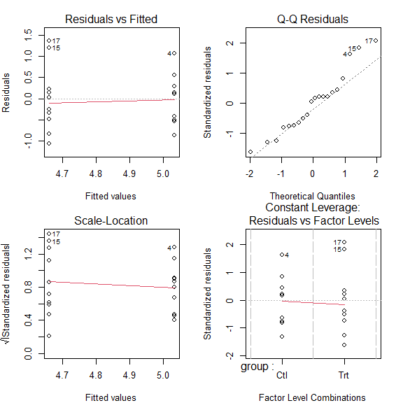

```r
ctl <- c(4.17, 5.58, 5.18, 6.11, 4.50, 4.61, 5.17, 4.53, 5.33, 5.14)
trt <- c(4.81, 4.17, 4.41, 3.59, 5.87, 3.83, 6.03, 4.89, 4.32, 4.69)
weight <- c(ctl, trt)
group <- gl(2, 10, 20, labels = c("Ctl", "Trt"))
lm.D9 <- lm(weight ~ group)
par(mfrow=c(2, 2))
par(mar=c(4, 4, 2.5, 2))
plot(lm.D9)
```

## Example 2

对R自带数据集iris进行kmeans聚类.

## Answer 2

下面是代码实现：

```r
set.seed(20240910)
ir = iris[,1:4]
myclust = kmeans(x=ir, centers=3, nstart=100) # 分为3类，迭代100次
labels = myclust$cluster
```

聚类效果如下表：

```r
targets = t(iris[5])
table(targets, labels)
```

```
##             labels
## targets       1  2  3
##   setosa      0  0 50
##   versicolor  2 48  0
##   virginica  36 14  0
```

可见错分率约为10.7%.

## Example 3

生成概率密度为
$$p(x)=\frac{1}{2}e^{-|x|}$$
的随机数.

## Answer 3

可以使用逆变换法. 通过简单计算可知上述密度函数对应的分布函数为
$$F(x)=\int_{-\infty}^x\frac{1}{2}e^{-|t|}\mathrm{d}t=\begin{cases}
\frac{1}{2}e^x & x\le 0\\
1-\frac{1}{2}e^{-x} & x > 0
\end{cases}.$$
其逆映射为
$$F^{-1}(x)=
\begin{cases}
\log(2x) & 0<x\le \frac{1}{2}\\
-\log(2-2x) & \frac{1}{2}<x<1
\end{cases}.$$
取$U\sim U(0,1)$，那么$F^{-1}(U)$服从目标分布.

下面是对应的代码实现：

```r
set.seed(20240910, kind=NULL)
u <- runif(10000)
x <- log(2*u)*(u<=0.5) - log(2-2*u)*(u>0.5)
```

下图是实验结果，柱状图为生成的随机数的频率图，红线为目标分布的密度函数.

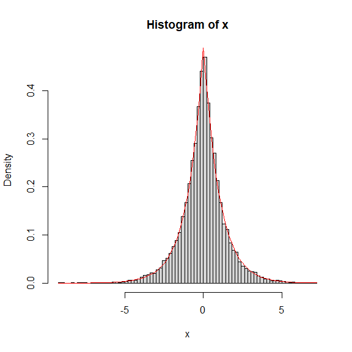

```r
hist(x, prob=TRUE, breaks=100)
DensityFunction <- function(x)
  return(0.5*exp(-abs(x)))
curve(DensityFunction, col='red', add=TRUE)
```

可见生成的效果很好.

# HW1

## Question 1: Exercise 3.4

The Rayleigh density is
$$f(x)=\frac{x}{\sigma^2}e^{-x^2/(2\sigma^2)},\quad
x\ge 0,\sigma>0.$$
Develop an algorithm to generate random samples from a Rayleigh(σ) distribution.

Generate Rayleigh(σ) samples for several choices of σ > 0 and check that the mode of the generated samples is close to the theoretical mode σ (check the histogram).

## Answer 1

### 1.算法

下面使用逆变换法来生成样本. 目标分布为
$$F(x)=\int_{0}^x\frac{t}{\sigma^2}e^{-t^2/(2\sigma^2)}\mathrm{d}t=1-e^{-x^2/(2\sigma^2)},\quad
x\ge0.$$
其逆为
$$F^{-1}(x)=\sqrt{-2\sigma^2\ln(1-x)}.$$
因此算法如下：

1. 生成$U\sim U(0,1)$.
2. 输出$X=F^{-1}(U)$.

### 2.验证

接下来我分别考察$\sigma = 0.1, 1, 10$的情况，每种情况生成10000个随机数.

上述算法的代码实现如下：

```r
RayleighGenerator <- function(n, sigma) {
  # n: 生成的随机数数目
  # sigma: 目标分布中的参数sigma
  # return: 一个长度为n的向量

  # 1. 生成均匀分布随机数U
  U <- runif(n)

  # 2. 输出X=F^{-1}(U)
  X <- sqrt(-2 * sigma^2 * log(1-U))

  return(X)
}
```

下面是不同$\sigma$取值下的实验结果：

```r
n <- 10000   # 生成随机数数目
sigmas <- c(0.1, 1, 10)
```

```r
set.seed(20240920)
X1 <- RayleighGenerator(n, sigmas[1])
X2 <- RayleighGenerator(n, sigmas[2])
X3 <- RayleighGenerator(n, sigmas[3])

# 整成dataframe用于画图
data1 <- data.frame(X = X1)
data2 <- data.frame(X = X2)
data3 <- data.frame(X = X3)
```

```r
# 目标分布的密度
TargetDensityGenerator <- function(sigma) {
  target <- function(x) {
    return(
      ( x / (sigma^2) * exp(-x^2/(2*sigma^2)) ) * ( x > 0 )
    )
  }
  return(target)
}
```

```r
# 画图函数
myplot <- function(data, sigma) {
  # data: 生成的随机数，必须是dataframe，只有一列，名为"X"
  # sigma: 目标分布的参数
  # return: 一个ggplot图，带有data决定的直方图和sigma决定的目标密度曲线

  n <- dim(data)[1]
  Figure <- ggplot(data, aes(x=X)) +
    geom_histogram(aes(y = after_stat(density)),
                   binwidth=3.5*sigma/(n^(1/3)),
                   fill='#74c0fc',
                   color="white") +
    # 使用Scott法选取binwidth，经我计算Rayleigh分布的方差就是sigma^2
    stat_function(fun = TargetDensityGenerator(sigma), color = '#fd7e14', linewidth = 1) +
    geom_vline(xintercept=sigma, linetype=2, linewidth=0.5) +
    # Rayleigh分布的众数就是sigma
    labs(x="X",
         y="Density",
         title=bquote(sigma ==. (sigma))) +   # 动态生成标题
    theme_bw() +
    theme(panel.grid = element_blank(),
          plot.title = element_text(hjust=0.5),
          legend.position = "none")

  return(Figure)
}
```

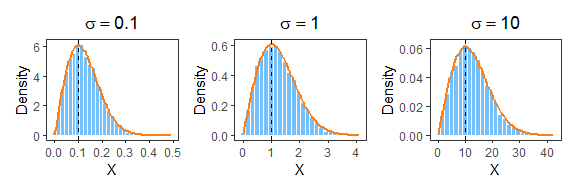

```r
Figure1 <- myplot(data1, sigmas[1])
Figure2 <- myplot(data2, sigmas[2])
Figure3 <- myplot(data3, sigmas[3])
Figure1 + Figure2 + Figure3
```

其中橙色曲线为目标密度函数，虚线表示的是理论众数，可见样本众数和理论众数是十分相近的，样本分布和目标分布也是极为相近.

## Question 2: Exercise 3.11

Generate a random sample of size 1000 from a normal location mixture. The components of the mixture have $N(0, 1)$ and $N(3, 1)$ distributions with mixing probabilities $p_1$ and $p_2 = 1 − p_1$.

Graph the histogram of the sample with density superimposed, for $p_1 = 0.75$.

Repeat with different values for p1 and observe whether the empirical distribution of the mixture appears to be bimodal. Make a conjecture about the values of p1 that produce bimodal mixtures.

## Answer 2

### 1.算法

这是个混合模型，生成随机数的算法如下：

1. 生成一个独立的潜变量$I$其满足$P(I=0)=p_1,\ P(I=1)=p_2$.
2. 若$I=0$，则从$N(0, 1)$中生成$X$. 若$I=1$，则从$N(3, 1)$中生成$X$.
3. 输出$X$.

上述算法的代码实现如下：

```r
MixNormGenerator <- function(n, p) {
  # n: 生成的随机数数目
  # p: p1的取值
  # return: 一个长度为n的向量

  # 1.生成潜变量I
  I <- sample(0:1, size=n, replace=TRUE, prob=c(p, 1-p))

  # 2.从两个分量中采样
  X1 <- rnorm(n, 0, 1)
  X2 <- rnorm(n, 3, 1)

  # 3.输出X
  X <- X1 * (1-I) + X2 * I
  return(X)
}
```

### 2.画直方图和目标密度

```r
# 这里写一个函数根据p1输出目标密度函数，方便后面画图的时候调用
TargetDensityGenerator <- function(p1) {
  target <- function(x) {
    return(p1*dnorm(x, 0, 1)+(1-p1)*dnorm(x, 3, 1))
  }
}
```

$p_1=0.75$时的实验结果如下，橙色曲线为目标密度，可见生成的效果不错.

```r
set.seed(20240921)
n <- 1000
p1 <- 0.75
X <- MixNormGenerator(n, p1)
data <- data.frame(X=X)
```

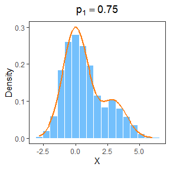

```r
Figure <- ggplot(data, aes(x=X)) +
  geom_histogram(aes(y = after_stat(density)),
                 binwidth=3.5*sd(data$X)/(n^(1/3)),
                 fill='#74c0fc',
                 color="white") +
  stat_function(fun = TargetDensityGenerator(p1), color = '#fd7e14', linewidth = 1) +
  labs(x="X",
       y="Density",
       title=bquote(p[1] ==. (p1))) +
  theme_bw() +
  theme(panel.grid = element_blank(),
        plot.title = element_text(hjust=0.5),
        legend.position = "none")

Figure
```

### 3.观察双峰性并推测导致双峰的参数范围

考虑$p_1$分别取$0.1, 0.2, 0.3,\cdots,0.9$时的情况，实验结果如下图所示：

```r
n <- 1000
ps <- seq(0.1, 0.9, 0.1)
```

```r
set.seed(20240921)

X1 <- MixNormGenerator(n, ps[1])
X2 <- MixNormGenerator(n, ps[2])
X3 <- MixNormGenerator(n, ps[3])
X4 <- MixNormGenerator(n, ps[4])
X5 <- MixNormGenerator(n, ps[5])
X6 <- MixNormGenerator(n, ps[6])
X7 <- MixNormGenerator(n, ps[7])
X8 <- MixNormGenerator(n, ps[8])
X9 <- MixNormGenerator(n, ps[9])

data1 <- data.frame(X=X1)
data2 <- data.frame(X=X2)
data3 <- data.frame(X=X3)
data4 <- data.frame(X=X4)
data5 <- data.frame(X=X5)
data6 <- data.frame(X=X6)
data7 <- data.frame(X=X7)
data8 <- data.frame(X=X8)
data9 <- data.frame(X=X9)
```

```r
myplot <- function(data, p) {
  n <- nrow(data)
  Figure <- ggplot(data, aes(x=X)) +
    geom_histogram(aes(y = after_stat(density)),
                   binwidth=3.5*sd(data$X)/(n^(1/3)),
                   fill='#74c0fc',
                   color="white") +
    labs(x="X",
         y="Density",
         title=bquote(p[1] ==. (p))) +   # 动态生成标题
    theme_bw() +
    theme(panel.grid = element_blank(),
          plot.title = element_text(hjust=0.5),
          legend.position = "none")
  return(Figure)
}
```

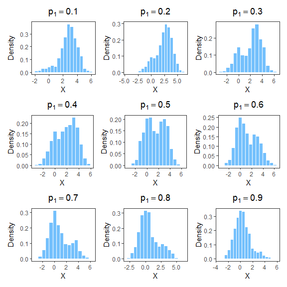

```r
Figure1 <- myplot(data1, ps[1])
Figure2 <- myplot(data2, ps[2])
Figure3 <- myplot(data3, ps[3])
Figure4 <- myplot(data4, ps[4])
Figure5 <- myplot(data5, ps[5])
Figure6 <- myplot(data6, ps[6])
Figure7 <- myplot(data7, ps[7])
Figure8 <- myplot(data8, ps[8])
Figure9 <- myplot(data9, ps[9])

(Figure1+Figure2+Figure3)/(Figure4+Figure5+Figure6)/(Figure7+Figure8+Figure9)
```

可见当$p_1=0.3,0.4,0.5,0.6,0.7$时双峰非常明显，而$p_1=0.2, 0.8$时双峰不明显，当$p_1=0.1,0.9$时基本没有双峰现象.

因此我推断当$p_1\in [0.3. 0.7]$时有双峰现象.

## Question 3: Exercise 3.20

A compound Poisson process is a stochastic process $\{X(t), t \ge 0\}$ that can be represented as the random sum $X(t) = \sum_{i=1}^{N(t)}Y_i,\ t ≥ 0$, where $\{N(t), t ≥ 0\}$ is a Poisson process and $Y_1, Y_2,\dots$ are iid and independent of $\{N(t), t ≥ 0\}$.

Write a program to simulate a compound Poisson(λ)–Gamma process (Y has a Gamma distribution).

Estimate the mean and the variance of X(10) for several choices of the parameters and compare with the theoretical values.

Hint: Show that $E[X(t)] = λtE[Y_1]$ and $Var(X(t)) = λtE[Y_1^2]$.

## Answer 3

### 1.算法

任意给定$t\ge0$，由于$X(t)|N(t)=k\sim Gamma(k*shape,rate)$，我给出如下算法生成$X(t)$：

1. 生成$N\sim Poisson(\lambda t)$.
2. 输出$X\sim Gamma(N*shape, rate)$.

代码实现如下：

```r
CPGPLocalGenerator <- function(n, lambda, shape, rate, t){
  # n: 生成的随机数数目
  # lambda: Poisson过程参数
  # shape, rate: Gamma分布参数
  # t: 时间参数
  # return: 一个长度为n的向量

  # remark: 这个函数只能生成X(t)的样本，不能生成一条轨道

  # 1.生成N
  N <- rpois(n, lambda*t)

  # 2.输出X
  X <- rgamma(n, shape=N*shape, rate=rate)
  return(X)
}
```

如果要生成一条轨道，由于此随机过程具有独立增量性，可以使用如下算法：

1. 输入参数$n$和$step$，$n$为样本点数目，$step$为步长.
2. 对于任意小于等于$n$的非负整数$i$，令$t_i=i*setp$.
3. 生成$X$:

   (1). $X_0=0$.

   (2). for i in 1:n :
   - 生成$\Delta N\sim Poisson(\lambda*step)$.
   - 生成$\Delta X\sim Gamma(shape*\Delta N, rate)$.
   - $X_i=X_{i-1}+\Delta X$.
4. 输出$\{(t_i,X_i)\}_{i=0}^n$.

其代码实现如下：

```r
CPGPTraceGenerator <- function(n, step, lambda, shape, rate) {
  # n: 生成的样本点数，算上t=0的点，实际上输出的是n+1个点
  # step: 步长
  # lambda: Poisson过程参数
  # shape, rate: Gamma分布参数
  # return: 一个(n+1)*2的dataframe，列名为"t"和"X"

  # 生成t
  t <- seq(from=0, by=step, length.out=n+1)

  # 生成X
  DeltaN <- rpois(n, lambda*step)
  DeltaX <- rgamma(n, shape=shape*DeltaN, rate=rate)
  X <- c(0, cumsum(DeltaX))

  # 生成dataframe
  data <- data.frame(t=t, X=X)

  return(data)
}
```

### 2.实验

首先看看$X(t)$的生成情况. 易见$X(t)$非负，$X(t)$的理论分布为
$$F(x)=\sum_{k=0}^\infty P(X(t)\le
x|N(t)=k)=P(N(t)=0)+\sum_{k=1}^\infty P(X(t)\le x|N(t)=k)P(N(t)=k),
\quad x\ge 0.$$

可以看到$F(x)$在$x>0$时是光滑的，此时的导数为
$$f(x)=\sum_{k=1}^{\infty}\frac{rate^{k*shape}}{\Gamma(k*shape)}x^{k*shape-1}e^{-rate*x}\frac{(\lambda
t)^k}{k!}e^{-\lambda t},\quad x>0.$$

接下来看看$\lambda=1$，$shape=1$，$rate=1$时生成的随机数的情况，此时$P(X(t)=0)=e^{-t}$，并且
$$f(x)=\sum_{k=1}^\infty\frac{(tx)^k}{k!(k-1)!}x^{-1}e^{-x-t}.$$

可用
$$g(x)=\sum_{k=1}^{20}\frac{(tx)^k}{k!(k-1)!}x^{-1}e^{-x-t}$$
来估计$f(x)$.

下面是$t=1,3,10$的情况，每种情况生成10000个随机数，实验结果如下图：

```r
set.seed(20240921)

lambda <- 1
shape <- 1
rate <- 1
n <- 10000
ts <- c(1, 3, 10)

X1 <- CPGPLocalGenerator(n, lambda, shape, rate, ts[1])
X2 <- CPGPLocalGenerator(n, lambda, shape, rate, ts[2])
X3 <- CPGPLocalGenerator(n, lambda, shape, rate, ts[3])

data1 <- data.frame(X=X1)
data2 <- data.frame(X=X2)
data3 <- data.frame(X=X3)
```

```r
TargetDensityGenerator <- function(t) {
  TargetDensity <- function(x) {
    result <- 0
    for (i in 1:20) {
      result <- result + t^i * x^{i-1} * exp(-x-t) / (factorial(i) * factorial(i-1))
    }
    return(result)
  }
  return(TargetDensity)
}

myplot <- function(data, t) {
  n <- nrow(data)
  Figure <- ggplot(data, aes(x=X)) +
    geom_histogram(aes(y = after_stat(density)), bins=50, fill='#74c0fc', color="white") +
    stat_function(fun = TargetDensityGenerator(t), color = '#fd7e14', linewidth = 0.7) +
    labs(x="X(t)",
         y="Density",
         title=bquote(t ==. (t))) +
    theme_bw() +
    theme(panel.grid = element_blank(),
          plot.title = element_text(hjust=0.5),
          legend.position = "none")
  return(Figure)
}
```

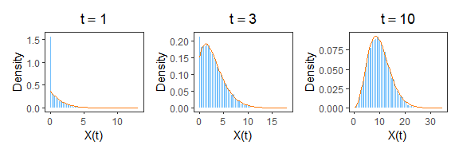

```r
Figure1 <- myplot(data1, ts[1])
Figure2 <- myplot(data2, ts[2])
Figure3 <- myplot(data3, ts[3])

Figure1+Figure2+Figure3
```

橙色曲线即为$g(x)$，可见生成的随机数在$X(t)>0$的时候效果很好. 而生成的随机数中$0$的频率和$P(X(t)=0)$的对比如下表：

```r
freq <- c(sum(X1==0)/n, sum(X2==0)/n, sum(X3==0)/n)
prob <- exp(-ts)
data.frame(t=ts, freq=freq, prob=prob)
```

```
##    t   freq         prob
## 1  1 0.3717 3.678794e-01
## 2  3 0.0503 4.978707e-02
## 3 10 0.0000 4.539993e-05
```

可见二者的差异很小. 因此我所生成的随机数效果不错.

再看看$\lambda=1$，$shape=1$，$rate=1$时生成的五条轨道：

```r
set.seed(20240921)

lambda <- 1
shape <- 1
rate <- 1
n <- 1000
step <- 0.1

data1 <- CPGPTraceGenerator(n, step, lambda, shape, rate)
data2 <- CPGPTraceGenerator(n, step, lambda, shape, rate)
data3 <- CPGPTraceGenerator(n, step, lambda, shape, rate)
data4 <- CPGPTraceGenerator(n, step, lambda, shape, rate)
data5 <- CPGPTraceGenerator(n, step, lambda, shape, rate)

data <- data.frame(t=data1$t, X1=data1$X, X2=data2$X, X3=data3$X, X4=data4$X, X5=data5$X)
```

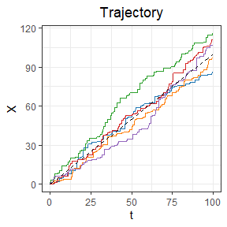

```r
Figure <- ggplot(data=data, aes(x=t)) +
  geom_line(aes(y=X1), color='#1F77B4FF') +
  geom_line(aes(y=X2), color='#FF7F0EFF') +
  geom_line(aes(y=X3), color='#2CA02CFF') +
  geom_line(aes(y=X4), color='#D62728FF') +
  geom_line(aes(y=X5), color='#9467BDFF') +
  stat_function(fun=function(x) {x}, col='black', linetype=2) +
  labs(x="t",
       y="X",
       title='Trajectory') +
  theme_bw() +
  theme(plot.title = element_text(hjust=0.5),
        legend.position = "none")

Figure
```

其中黑色虚线为$E(X(t))$，彩色实线为生成的轨道.

目标随机过程是单增的，这些生成的轨道也都是单增的. 注意到轨迹形似阶梯函数，有很多与$t$轴平行的线段，这和$N(t)$是Poisson过程是相符的. 各轨道围绕在均值附近振动. 这都说明我所生成的轨道是合理的.

### 3.估计

易得
$$E[X(t)]=E\left[E\left[X(t)|N(t)\right]\right]=E[N(t)E(Y_1)]=E(N(t))E(Y_1)=\lambda
tE(Y_1).$$

同理
$$E[X(t)^2]=E\left[\sum_{i,j=1}^{N(t)}Y_iY_j\Bigg|N(t)\right]=E\left[N(t)E(Y_1^2)+(N(t)^2-N(t))(EY_1)^2\right]=\lambda
tE(Y_1^2)+(\lambda t)^2(EY_1)^2.$$

因此$Var(X(t))=E(X(t)^2)-(E(x(t)))^2=\lambda t E(Y_1^2)$.

根据Gamma分布的性质可知，$E(Y_1)=shape/rate$，$Var(Y_1)=shape/rate^2$，$E(Y_1^2)=(shape+shape^2)/rate^2$.

下面就$\lambda=0.1,1,10$，$shape=1,2$，$rate=1,2$的情况估计$X(10)$的均值和方差，每组参数下生成10000个随机数，使用的估计量为样本均值和样本方差.

实验结果如下表：

```r
# 此函数用于生成不同参数下的理论值和估计值
Estimator <- function(n, lambdas, shapes, rates, t) {
  # n: 估计时所用样本数
  # lambdas: Poisson过程参数，一个任意长度的向量
  # shapes, rates: Gamma分布参数，两个都是任意长度的向量
  # t: 时间参数，只能输入一个正数
  # return: 一个dataframe，各列分别为lambda, shape, rate,
  #         theoretical_mean, estimated_mean, theoretical_variance, estimated_variance

  estimated_mean <- c()
  estimated_variance <- c()
  theoretical_mean <- c()
  theoretical_variance <- c()

  # 首先将lambdas, shapes, rates的取值的各种组合生成出来
  paras <- expand.grid(lambdas, shapes, rates)
  colnames(paras) <- c('lambda', 'shape', 'rate')

  # 生成估计值和理论值
  for (i in 1:nrow(paras)) {
    Tmean <- paras[i, ]$lambda * t * paras[i, ]$shape / paras[i, ]$rate
    Tvariance <- paras[i, ]$lambda * t * (paras[i, ]$shape + paras[i, ]$shape^2) / (paras[i, ]$rate^2)
    theoretical_mean <- c(theoretical_mean, Tmean)
    theoretical_variance <- c(theoretical_variance, Tvariance)

    X <- CPGPLocalGenerator(n, paras[i, ]$lambda, paras[i, ]$shape, paras[i, ]$rate, t)
    estimated_mean <- c(estimated_mean, mean(X))
    estimated_variance <- c(estimated_variance, var(X))
  }

  # 生成dataframe
  data <- paras
  data$theoretical_mean <- theoretical_mean
  data$estimated_mean <- estimated_mean
  data$theoretical_variance <- theoretical_variance
  data$eatimated_variance <- estimated_variance

  return(data)
}
```

```r
set.seed(20240922)

n <- 10000
lambdas <- c(0.1, 1, 10)
shapes <- c(1, 2)
rates <- c(1, 2)
t <- 10

data <- Estimator(n, lambdas, shapes, rates, t)

print(data)
```

```
##    lambda shape rate theoretical_mean estimated_mean theoretical_variance
## 1     0.1     1    1              1.0      0.9709390                  2.0
## 2     1.0     1    1             10.0      9.9341948                 20.0
## 3    10.0     1    1            100.0    100.2994099                200.0
## 4     0.1     2    1              2.0      1.9789704                  6.0
## 5     1.0     2    1             20.0     19.9273085                 60.0
## 6    10.0     2    1            200.0    199.9127864                600.0
## 7     0.1     1    2              0.5      0.4924856                  0.5
## 8     1.0     1    2              5.0      5.0110995                  5.0
## 9    10.0     1    2             50.0     49.9842772                 50.0
## 10    0.1     2    2              1.0      1.0068288                  1.5
## 11    1.0     2    2             10.0     10.0593934                 15.0
## 12   10.0     2    2            100.0     99.9764885                150.0
##    eatimated_variance
## 1           1.9389681
## 2          19.6391534
## 3         202.8991460
## 4           5.8629514
## 5          61.8166171
## 6         597.7703624
## 7           0.5053612
## 8           5.2171699
## 9          50.4554779
## 10          1.5021963
## 11         15.1430588
## 12        143.0425550
```

可见估计值和理论值之间非常接近.

# HW2

## Question 1: Exercise 5.4

Write a function to compute a Monte Carlo estimate of the Beta(3, 3) cdf, and use the function to estimate F(x) for x = 0.1, 0.2,…, 0.9. Compare the estimates with the values returned by the pbeta function in R.

## Answer 1

### 1.算法及代码实现

$Beta(3,3)$的密度为
$$f(x)=30x^2(1-x)^2,\quad 0\le x\le 1.$$
那么对应的分布函数为
$$F(x)=\int_0^x
30t^2(1-t)^2\mathrm{d}t.$$
当$0\le x\le 1$时，$F(x)=30x\mathbb{E}[U^2(1-U)^2]$，其中$U\sim U(0,x)$.

因此有如下算法：

1. 生成$n$个$U(0,x)$随机数$u_1,\cdots,u_n$.
2. 输出$\frac{30x}{n}\sum_{i=1}^n u_i^2(1-u_i)^2$.

代码实现如下：

```r
pbetaEstimator <- function(x, n) {
  # x: 目标F(x)中的x
  # n: 估计所使用的随机数数目
  # return: 输出估计

  # 0.排除x小于零或者大于一的情况
  if (x < 0) {
    return(0)
  }

  if (x > 1) {
    return(1)
  }

  # 1.生成U
  u <- runif(n, 0, x)

  # 2.输出估计
  return(30*x*mean(u^2*(1-u)^2))
}
```

### 2.实验结果

实验结果如下表：

```r
set.seed(20240927)
n <- 1000
estimates <- c()
contrast <- c()
for (i in 1:9) {
  estimates[i] <- pbetaEstimator(0.1*i, n)
  contrast[i] <- pbeta(0.1*i, 3, 3)
}
data.frame(x=seq(0.1, 0.9, 0.1), estimate=estimates, contrast=contrast, error=estimates-contrast)
```

```
##     x    estimate contrast         error
## 1 0.1 0.008845934  0.00856  0.0002859336
## 2 0.2 0.055452430  0.05792 -0.0024675698
## 3 0.3 0.161187751  0.16308 -0.0018922488
## 4 0.4 0.309245599  0.31744 -0.0081944006
## 5 0.5 0.495478724  0.50000 -0.0045212763
## 6 0.6 0.663529285  0.68256 -0.0190307155
## 7 0.7 0.825432885  0.83692 -0.0114871153
## 8 0.8 0.930976967  0.94208 -0.0111030327
## 9 0.9 0.993032522  0.99144  0.0015925218
```

可见二者差异很小.

## Question 2: Exercise 5.9

The Rayleigh density is
$$f(x)=\frac{x}{\sigma^2}e^{-x^2/(2\sigma^2)},\quad
x\ge 0,\sigma>0.$$

Implement a function to generate samples from a Rayleigh(σ) distribution, using antithetic variables.

## Answer 2

使用逆变换法生成随机数. 目标分布的逆为
$$F^{-1}(x)=\sqrt{-2\sigma^2\ln(1-x)}.$$

```r
inverseF <- function(x, sigma) {
  return(sqrt(-2 * sigma^2 * log(1-x)))
}
```

接下来我考虑$\sigma=1$时的情况，两种方法都使用2000个随机数.

```r
n <- 1000 # 随机数数目的一半
sigma <- 1
```

下面是不使用对偶变量生成随机数的代码实现：

```r
set.seed(20240928)
u1 <- runif(n)
u2 <- runif(n)
v1 <- inverseF(u1, sigma)
v2 <- inverseF(u2, sigma)
variance1 <- var((v1+v2)/2)
```

下面是使用对偶变量生成随机数的代码实现：

```r
set.seed(20240928)
u1 <- runif(n)
u2 <- 1 - u1
v1 <- inverseF(u1, sigma)
v2 <- inverseF(u2, sigma)
variance2 <- var((v1+v2)/2)
```

因此方差减少了

```r
(variance1-variance2)/variance1
```

```
## [1] 0.9506483
```

## Question 3: Exercise 5.13

Find two importance functions $f_1$ and $f_2$ that are supported on $(1, +\infty)$ and are ‘close’ to
$$g(x) = \frac{x^2}{
\sqrt{2\pi}} e^{−x^2/2}, \quad x> 1.$$

Which of your two importance functions should produce the smaller variance in estimating
$$\int_1^{\infty}\frac{x^2}{\sqrt{2\pi}}e^{-x^2/2}\mathrm{d}x$$
by importance sampling? Explain.

## Answer 3

### 1.找重要性函数

我们选出的重要性函数应该尽可能接近$g(x)$，下面先看看$g(x)$的形状.

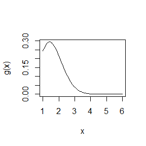

```r
g <- function(x) {
  return(x^2*exp(-x^2/2)/sqrt(2*pi))
}

curve(g, xlim=c(1,6))
```

可以看到$g(x)$先增再减，其次注意到$g(x)$并不是厚尾的， 因此可以选择$Gamma$分布作为重要性函数.

从另一方面看，$g(x)$基本是单调递减的，只有$x\in[1,\sqrt{2}]$时$g(x)$是单调递增的，同时$g(x)$在零附近的密度显著地大于零，因此也可以选择指数分布作为重要性函数.

综上所述，我选取
$$f_1(x)=4(x-1)e^{-2(x-1)},\quad x> 1.$$
以及
$$f_2(x)=e^{-(x-1)},\quad
x>1.$$

二者和$g(x)$的形状比较如下图所示：

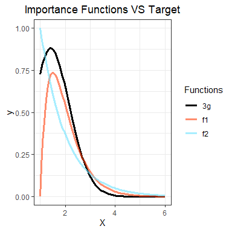

```r
Figure <- ggplot() +
  stat_function(fun = function(x) {3*g(x)}, aes(color="3g"), linewidth = 1.3) +
  stat_function(fun = function(x) {dgamma(x-1, shape=2, rate=2)}, aes(color="f1"), linewidth = 1.3) +
  stat_function(fun = function(x) {dexp(x-1, rate=1)}, aes(color="f2"), linewidth = 1.3) +
  xlim(1, 6) +
  labs(x="X",
       y="y",
       title="Importance Functions VS Target",
       color="Functions") +
  scale_color_manual(values=c("3g"="black", "f1"="#FF410D99", "f2"="#6EE2FF99")) +
  theme_bw() +
  theme(plot.title = element_text(hjust=0.5))

Figure
```

图中黑色曲线是$3g(x)$，这里乘一个倍数是为了方便比较这三个函数的形状. 可见我选取的两个重要性函数和$g(x)$都比较’close’.

### 2.比较二者的效果

先实现重要性采样法：

```r
ISEstimator <- function(n, type) {
  # n: 估计所使用的样本数
  # type: 只能取1和2，表示取f1还是f2
  # return: 估计值

  if (type == 1) {
    x <- rgamma(n, shape=2, rate=2)
    result <- mean(g(x+1)/dgamma(x, shape=2, rate=2))
  }
  if (type == 2) {
    x <- rexp(n, 1)
    result <- mean(g(x+1)/dexp(x, 1))
  }

  return(result)
}
```

通过分部积分，我们可以计算得
$$\int_1^\infty
g(x)\mathrm{d}x=\frac{1}{\sqrt{2\pi}}e^{-1/2}+\int_1^\infty\frac{1}{\sqrt{2\pi}}e^{-x^2/2}\mathrm{d}x.$$
可见右侧第二项是标准正态分布大于1的概率.

当$n=1000$时估计结果如下

```r
set.seed(20240928)
n <- 1000
target <- exp(-0.5)/sqrt(2*pi) + pnorm(-1) # 根据标准正态分布的对称性，其大于1的概率等于其小于-1的概率
data.frame(f1=ISEstimator(n, 1), f2=ISEstimator(n, 2), target=target)
```

```
##          f1        f2   target
## 1 0.3989961 0.4044094 0.400626
```

可见两个估计值都与理论值相近.

下面通过蒙特卡罗方法估计两种估计的方差.

```r
m <- 1000
set.seed(20240928)
result1 <- c()
result2 <- c()
for (i in 1:m) {
  result1 <- c(result1, ISEstimator(n, 1))
  result2 <- c(result2, ISEstimator(n, 2))
}
variance1 <- var(result1)
variance2 <- var(result2)
data.frame(variance1=variance1, variance2=variance2)
```

```
##      variance1    variance2
## 1 7.857734e-05 2.557967e-05
```

可见使用$f_2$的时候方差更小.

## Question 4

For $n=10^4,2\times 10^4,4\times 10^4, 6\times 10^4, 8\times 10^4$, apply the fast sorting algorithm to randomly permuted numbers of $1,\cdots,n$.

Calculate computation time averaged over 100 simulations, denoted by $a_n$.

Regress $a_n$ on $t_n:=n\log n$, and graphically show the results (scatter plot and regression line).

## Answer 4

### 1. 算法以及代码实现

算法如下：

1. 如果序列长度小于等于1则停止.
2. 将序列第一个元素记为$x$，将比$x$小的元素移动到$x$左侧，将比$x$大的元素移到$x$右侧.
3. 对$x$左右两侧两个子序列重复上述两个步骤

使用递归的方法实现这个算法：

```r
QuickSort <- function(v) {
  # 1. 如果长度小于等于一则停止
  if (length(v) <= 1) {
    return(v)
  }
  x <- v[1]

  # 2. 分成两个新向量
  v1 <- v[v < x]
  v2 <- v[v > x]

  # 3. 对v1和v2重复上述步骤
  result <- c(QuickSort(v1), x, QuickSort(v2))

  return(result)
}
```

### 2. 考察计算时间和nlog(n)之间的关系

$a_n$计算结果如下：

```r
set.seed(20240928)
ns <- c(1e4, 2e4, 4e4, 6e4, 8e4)
an <- c()
for (n in ns) {
  ts <- c()
  for (i in 1:100) {
    v <- sample(1:n)

    t1 <- Sys.time()
    v <- QuickSort(v)
    t2 <- Sys.time()

    ts <- c(ts, t2-t1)
  }
  an <- c(an, mean(ts))
}

data <- data.frame(tn=ns*log(ns), an=an)
data
```

```
##         tn         an
## 1  92103.4 0.01543624
## 2 198069.8 0.02926806
## 3 423865.4 0.05999350
## 4 660126.0 0.08277368
## 5 903182.6 0.11241215
```

```r
# 我这里设置了seed但在不同的实验中a_n的值还是有波动，我怀疑是计算机自身造成的
```

$a_n$和$t_n$的散点图和回归线如下图所示：

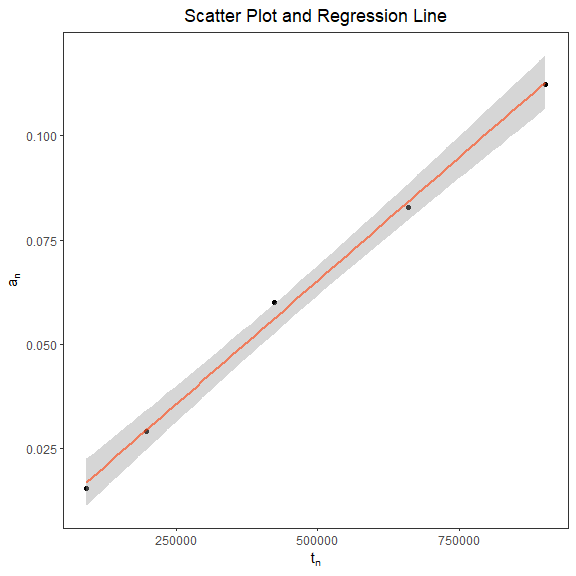

```r
Figure <- ggplot(data=data, aes(x=tn, y=an)) +
  geom_point() +
  geom_smooth(method="lm", color="#FF410D99") +
  labs(x=expression(t[n]),
         y=expression(a[n]),
         title='Scatter Plot and Regression Line') +
  theme_bw() +
  theme(panel.grid = element_blank(),
        plot.title = element_text(hjust=0.5),
        legend.position = "none")

Figure
```

# HW3

## Question 1: Exercise 6.6

Estimate the 0.025, 0.05, 0.95, and 0.975 quantiles of the skewness $\sqrt{b_1}$ under normality by a Monte Carlo experiment.

Compute the standard error of the estimates from
$$\mathrm{Var}(\hat{x}_q)=\frac{q(1-q)}{nf(x_q)^2},$$
using the normal approximation for the density (with exact variance formula).

Compare the estimated quantiles with the quantiles of the large sample approximation $\sqrt{b_1}\approx N(0,6/n)$.

## Answer 1

$\sqrt{b_1}$的表达式如下：
$$\sqrt{b_1}=\frac{\frac{1}{n}\sum_{i=1}^n(X_i-\bar{X})^3}{(\frac{1}{n}\sum_{i=1}^n(X_i-\bar{X})^2)^{3/2}}.$$

```r
Skewness <- function(x) {
  # x: 样本
  # return: 样本对应的样本偏度系数

  a <- mean((x-mean(x))^3)
  b <- var(x)^1.5

  return(a/b)
}
```

### 1. 估计分位数

每次实验的代码实现如下：

```r
MC <- function(q, n, m) {
  # q: q分位数，这里q可以为向量
  # n: \sqrt{b_1}中的n
  # m: 重复次数
  # return: 一个长度和q相同的向量，每一项为对应的q分位数

  bs <- replicate(m, expr = {
    x <- rnorm(n)
    Skewness(x)
  })

  return(quantile(bs, q))
}
```

不妨取$n=100$，每次实验重复$m=10000$次.

```r
set.seed(20241002)
n <- 100
m <- 10000
qs <- c(0.025, 0.05, 0.95, 0.975)

result1 <- MC(qs, n, m)
result1
```

```
##       2.5%         5%        95%      97.5%
## -0.4604299 -0.3781228  0.3735846  0.4518387
```

### 2. 计算标准差

根据教材一第167页第七行，我使用如下公式计算$\sqrt{b_1}$的方差：
$$\mathrm{Var}(\sqrt{b_1})=\frac{6(n-2)}{(n+1)(n+3)}.$$
因此用$N\left(0, \frac{6(n-2)}{(n+1)(n+3)}\right)$作为$\sqrt{b_1}$的分布的近似. 因此有如下函数计算标准差：

```r
SD <- function(q, n, m) {
  # q: q分位数
  # n: \sqrt{b_1}中的n
  # m: 估计分位数时一次MC实验中重复m次
  # return: 使用正态近似\sqrt{b_1}分布后的理论标准差

  variance <- 6 * (n-2) / ((n+1) * (n+3))
  f <- dnorm(qnorm(q, 0, sqrt(variance)), 0, sqrt(variance))
  return(q*(1-q)/(m*f^2))
}
```

结果如下：

```r
SD(qs, n, m)
```

```
## [1] 4.033366e-05 2.524032e-05 2.524032e-05 4.033366e-05
```

### 3. 比较

```r
result2 <- qnorm(qs, 0, sqrt(6/n))
data.frame(Estimate=result1, LargeSample=result2)
```

```
##         Estimate LargeSample
## 2.5%  -0.4604299  -0.4800912
## 5%    -0.3781228  -0.4029052
## 95%    0.3735846   0.4029052
## 97.5%  0.4518387   0.4800912
```

可以发现二者有一定的差异.

如果将方差计算方式换成
$$\mathrm{Var}(\sqrt{b_1})=\frac{6(n-2)}{(n+1)(n+3)}.$$
结果如下：

```r
result3 <- qnorm(qs, 0, sqrt(6*(n-2)/((n+1)*(n+3))))
data.frame(Estimate=result1, LargeSample=result2, NewLargeSample=result3)
```

```
##         Estimate LargeSample NewLargeSample
## 2.5%  -0.4604299  -0.4800912     -0.4659695
## 5%    -0.3781228  -0.4029052     -0.3910539
## 95%    0.3735846   0.4029052      0.3910539
## 97.5%  0.4518387   0.4800912      0.4659695
```

可以发现更改方差后，估计值和大样本近似值更加接近，但接近程度还是不理想.

## Question 2: Exercise 6.B

Tests for association based on Pearson product moment correlation $\rho$, Spearman’s rank correlation coefficient $\rho_s$, or Kendall’s coefficient $\tau$, are implemented in $\mathsf{cor.test}$.

Show (empirically) that the nonparametric tests based on $\rho_s$ or $\tau$ are less powerful than the correlation test when the sampled distribution is bivariate normal.

Find an example of an alternative (a bivariate distribution $(X,Y)$ such that $X$ and $Y$ are dependent) such that at least one of the nonparametric tests have better empirical power than the correlation test against this alternative.

## Answer 2

在相关性检验中，原假设为$H_0:X$和$Y$不相关，对立假设为$H_a:X$和$Y$相关.

### 1. 比较Power

要比较Power，首先要确定一个置信水平$\alpha$，然后由$P_{H_a}(p-value\le\alpha)$得到对应的Power，再进行比较. 设采样分布为二维正态$N(0,\Sigma)$.

```r
PowerEstimator <- function(method, Sigma, alpha, n, m) {
  # method: 检验方法，只能输入"Pearson"、“Spearman”和"Kendall"
  # Sigma: 二元正态的协方差矩阵
  # alpha: 置信水平
  # n: 一次检验所使用的样本数
  # m: 一次MC实验中重复的次数
  # return: 对应方法的Power的估计值

  tmp <- replicate(m, expr = {
    # 1. 生成n个样本
    samples <- mvrnorm(n, c(0, 0), Sigma)
    x <- samples[, 1]
    y <- samples[, 2]

    # 2. 进行检验
    result <- cor.test(x, y, method=method)

    # 3. 是否拒绝
    result$p.value <= alpha
  })

  return(mean(tmp))
}
```

为了简单起见，我考虑形如$\begin{bmatrix}1 & \sigma \\ \sigma & 1\end{bmatrix}$的$\Sigma$. 取$n=100,m=1000,\alpha=0.01$，$\sigma$取$0.2, 0.3, 0.4, 0.5$时实验结果如下：

```r
set.seed(20241002)

n <- 100
m <- 1000
alpha <- 0.01
sigmas <- c(0.2, 0.3, 0.4, 0.5)

for (sigma in sigmas) {

}

PPowers <- sapply(sigmas, function(x) PowerEstimator("pearson", matrix(c(1,x,x,1),2,2), alpha, n, m))

SPowers <- sapply(sigmas, function(x) PowerEstimator("spearman", matrix(c(1,x,x,1),2,2), alpha, n, m))

KPowers <- sapply(sigmas, function(x) PowerEstimator("kendall", matrix(c(1,x,x,1),2,2), alpha, n, m))

data.frame(sigma=sigmas, Pearson=PPowers, Spearman=SPowers, Kendall=KPowers)
```

```
##   sigma Pearson Spearman Kendall
## 1   0.2   0.269    0.234   0.251
## 2   0.3   0.668    0.588   0.636
## 3   0.4   0.943    0.907   0.909
## 4   0.5   0.999    0.997   0.996
```

可以看到在不同的$\sigma$取值下，基于Pearson相关系数的检验始终更有效.

### 2. 找例子

我们知道Pearson相关系数只能衡量线性相关关系，不容易捕获到非线性关系，因此只需给$X$和$Y$一个强烈的非线性关系即可， 比如直接取$E(Y|X)=I(X>0)$.

下面我考虑这样的一个二元分布：$X\sim N(0,1)$，$Y|X\sim N(I(X>0),1)$.

```r
PowerEstimator <- function(method, alpha, n, m) {
  # method: 检验方法，只能输入"Pearson"、“Spearman”和"Kendall"
  # alpha: 置信水平
  # n: 一次检验所使用的样本数
  # m: 一次MC实验中重复的次数
  # return: 对应方法的Power的估计值

  tmp <- replicate(m, expr = {
    # 1. 生成n个样本
    x <- rnorm(n)
    y <- as.numeric(x>0) + rnorm(n)

    # 2. 进行检验
    result <- cor.test(x, y, method=method)

    # 3. 是否拒绝
    result$p.value <= alpha
  })

  return(mean(tmp))
}
```

取$\alpha=0.01,n=100,m=1000$，实验结果如下：

```r
set.seed(20241002)

n <- 100
m <- 1000
alpha <- 0.01

PPower <- PowerEstimator("pearson", alpha, n, m)
SPower <- PowerEstimator("spearman", alpha, n, m)
KPower <- PowerEstimator("kendall", alpha, n, m)

data.frame(Pearson=PPower, Spearman=SPower, Kendall=KPower)
```

```
##   Pearson Spearman Kendall
## 1    0.87     0.92    0.93
```

可见此时两种非参方法效果都更好.

## Question 3

If we obtain the powers for two methods under a particular simulation setting with 10,000 experiments: say, 0.651 for one method and 0.676 for another method. We want to know if the powers are different at 0.05 level.

What is the corresponding hypothesis test problem?

What test should we use? Z-test, two-sample t-test, paired-t test or McNemar test? Why?

Please provide the least necessary information for hypothesis testing.

## Answer 3

### 1. 原假设与对立假设

设这两种方法所应对的假设检验的原假设为$H_0$，对立假设为$H_a$. 将两种方法记为$M_1$和$M_2$. 记$\beta_i=P(reject\ H_0\ using\ M_i|H_a),\ i=1,2$.

因此Question 3 对应的假设检验为：$H'_0:\beta_1=\beta_2\leftrightarrow H'_a:\beta_1\ne\beta_2$.

### 2. 检验的方法

记$I_{ki}$为“在$H_a$成立的条件下第$k$次实验中使用$M_i$拒绝$H_0$”的示性函数，那么$I_{ki}\sim B(1,\beta_i)$. 从题意看，应该是每次实验生成样本后，基于这些生成的样本分别使用两种方法进行假设检验，因此$I_{k1}$和$I_{k2}$是相关的，而$\{(I_{k1},I_{k2})\}_{k=1}^m$是独立的. 记$p_i=\frac{1}{m}\sum_{k=1}^m I_{ki},\ i=1,2$，可见$p_i$即为$M_i$的Power的估计值.

从题目给的信息来看，我确切能知晓的数据只有$p_i$，而不知晓$I_{ki}$的具体取值. 在这种情况下，我认为这四种方法都是行不通的.

#### (1). Z-test

由于$\beta_1-\beta_2=E(I_{k1}-I_{k2})$，因此实际上是要检验$I_{k1}-I_{k2}$的总体均值是否为零. 而且在$H'_0$成立时，我们很容易得到CLT：
$$\frac{\sqrt{m}(p_1-p_2)}{\sqrt{\mathrm{Var}(I_{11}-I_{12})}}=\frac{\sqrt{m}\left(\frac{1}{m}\sum_{k=1}^m(I_{k1}-I_{k2})\right)}{\sqrt{\mathrm{Var}(I_{11}-I_{12})}}\to
N(0,1)\quad m\to\infty.$$
那么如果要进行Z-test，现在只需要找到一个办法估计$\mathrm{Var}(I_{11}-I_{12})$. 如果我们知道所有$I_{ki}$的取值，那么直接使用$\{I_{k1}-I_{k2}\}$的样本二阶矩来估计就行了(在$H'_0$成立时$I_{k1}-I_{k2}$的总体方差等于总体二阶矩). 但是如果我们不知道$I_{ki}$，只有$p_1$和$p_2$，我们就估计不了这个方差，因为我们处理不了$\mathrm{Cov}(I_{11},I_{12})$.

如果我们知道所有$I_{ki}$的取值，使用
$$\frac{\sqrt{m}(p_1-p_2)}{\sqrt{\frac{1}{m}\sum_{k=1}^m(I_{k1}-I_{k2})^2}}=\frac{\sqrt{m}(p_1-p_2)}{\sqrt{p_1+p_2-\frac{2}{m}\sum_{k=1}^mI_{k1}I_{k2}}}\to
N(0,1).$$
即可进行Z-test.

#### (2). two-sample t-test and paired-t test

这都不是正态总体，显然不能使用t-test.

就算是考虑大样本情形，由于$I_{k1}$和$I_{k2}$不独立，显然two-sample t-test也是不能用的. 而对于paired-t test，它的情况和前面的Z-test是类似的，如果只知道$p_1$和$p_2$是无法得到$\{I_{k1}-I_{k2}\}$的样本标准差的.

#### (3). McNemar test

“$M_1$接受$H_0$而$M_2$拒绝$H_0$”的频数为$\sum_{k=1}^mI_{k2}(1-I_{k1})$，“$M_1$拒绝$H_0$而$M_2$接受$H_0$”的频数为$\sum_{k=1}^mI_{k1}(1-I_{k2})$. 因此对应的McNemar检验统计量为
$$\chi^2=\frac{m^2(p_1-p_2)^2}{mp_1+mp_2-2\sum_{k=1}^mI_{k1}I_{k2}}.$$

可以看到，如果我们只有$p_1$和$p_2$，我们也是无法得到$\chi^2$. 另外我们可以注意到这个统计量实际上是我在前面给出的Z-test统计量的平方.

### 3. 检验所需信息

从上述讨论可以发现，已知$p_1$和$p_2$的情况下，要进行假设检验，还需要知道$\sum_{k=1}^mI_{k1}I_{k2}$即“$M_1$和$M_2$都拒绝$H_0$”的频数.

# HW4

## Question 1:

Of $N = 1000$ hypotheses, 950 are null and 50 are alternative. The p-value under any null hypothesis is uniformly distributed (use runif), and the p-value under any alternative hypothesis follows the beta distribution with parameter 0.1 and 1 (use rbeta).

Obtain Bonferroni adjusted p-values and B-H adjusted p-values.

Calculate FWER, FDR, and TPR under nominal level $\alpha$ = 0.1 for each of the two adjustment methods based on $m = 10000$ simulation replicates.

You should output the 6 numbers (3 ) to a 3 × 2 table (column names: Bonferroni correction, B-H correction; row names: FWER, FDR, TPR).

Comment the results.

## Answer 1:

```r
alpha <- 0.1
m <- 10000
N <- 1000
N0 <- 950
```

```r
set.seed(20241016)

result1 <- replicate(m, expr={
  ps <- c(runif(N0), rbeta(N-N0, 0.1, 1))
  ps.Bon <- p.adjust(ps, method="bonferroni")
  ps.BH <- p.adjust(ps, method="fdr")

  V.Bon <- sum(ps.Bon[1:N0]<alpha)
  S.Bon <- sum(ps.Bon[(N0+1):N]<alpha)
  R.Bon <- V.Bon + S.Bon

  V.BH <- sum(ps.BH[1:N0]<alpha)
  S.BH <- sum(ps.BH[(N0+1):N]<alpha)
  R.BH <- V.BH + S.BH

  FWER.Bon <- as.numeric(V.Bon>0)
  FDR.Bon <- V.Bon / R.Bon
  TPR.Bon <- S.Bon / (N - N0)

  FWER.BH <- as.numeric(V.BH>0)
  FDR.BH <- V.BH / R.BH
  TPR.BH <- S.BH / (N - N0)

  c(FWER.Bon, FDR.Bon, TPR.Bon, FWER.BH, FDR.BH, TPR.BH)
})

result2 <- rowMeans(result1)
result3 <- data.frame(Bonferroni=result2[1:3], BH=result2[4:6])
rownames(result3) <- c("FWER", "FDR", "TPR")
result3
```

```
##      Bonferroni         BH
## FWER 0.09380000 0.93260000
## FDR  0.00486222 0.09591136
## TPR  0.39765800 0.56193000
```

使用Bonferroni修正时，$\mathrm{FWER}=0.0938< 0.1=\alpha$，这印证了Bonferroni修正能控制FWER，使之小于$\alpha$. 使用B-H修正时，$\mathrm{FDR}=0.09591136<0.1=\alpha$，这也印证了B-H修正能将FDR控制在$\alpha$以下. 使用Bonferroni修正时，各项指标都比使用B-H修正时低，这说明了Bonferroni修正的保守。

## Question 2: Exercise 7.4

Refer to the air-conditioning data set $\textsf{aircondit}$ provided in the $\textsf{boot}$ package. The 12 observations are the times in hours between failures of airconditioning equipment:
$$3, 5, 7, 18, 43, 85, 91, 98,
100, 130, 230, 487.$$
Assume that the times between failures follow an exponential model $\mathrm{Exp}(\lambda)$.

Obtain the MLE of the hazard rate $\lambda$ and use bootstrap to estimate the bias and standard error of the estimate.

## Answer 2:

记第$i$个观测量为$X_i$，$X_i\sim \mathrm{Exp}(\lambda)$. 则对数似然函数为
$$l=\sum_{i=1}^n(\ln\lambda-\lambda X_i).$$
则$\lambda$的MLE为$\hat{\lambda}=1/\bar{X}$.

```r
lambda.hat <- 1/mean(aircondit$hours)
lambda.hat
```

```
## [1] 0.00925212
```

使用bootstrap估计此估计量的偏差和标准差的结果如下

```r
set.seed(20241016)
MLE <- function(x, i) 1/mean(x[i])
result <- boot::boot(data=boot::aircondit$hours, statistic=MLE, R=1e4)
round(c(original=result$t0, bias=mean(result$t)-result$t0, se=sd(result$t)), 3)
```

```
## original     bias       se
##    0.009    0.001    0.004
```

## Question 3: Exercise 7.5

Refer to Exercise 7.4. Compute 95% bootstrap confidence intervals for the mean time between failures $1/\lambda$ by the standard normal, basic, percentile, and BCa methods. Compare the intervals and explain why they may differ.

## Answer 3:

使用$\bar{X}$估计$1/\lambda$.

```r
set.seed(20241016)
boot.mean <- function(x, i) mean(x[i])
boot.obj <- boot::boot(data=boot::aircondit$hours, statistic=boot.mean, R=1e4)
CI <- boot::boot.ci(boot.obj, conf=0.95, type=c("norm", "basic", "perc", "bca"))
CI
```

```
## BOOTSTRAP CONFIDENCE INTERVAL CALCULATIONS
## Based on 10000 bootstrap replicates
##
## CALL :
## boot::boot.ci(boot.out = boot.obj, conf = 0.95, type = c("norm",
##     "basic", "perc", "bca"))
##
## Intervals :
## Level      Normal              Basic
## 95%   ( 35.1, 182.0 )   ( 25.0, 169.2 )
##
## Level     Percentile            BCa
## 95%   ( 46.9, 191.2 )   ( 56.7, 225.9 )
## Calculations and Intervals on Original Scale
```

得到的置信区间为:

(1). Standard normal: (35.1, 182.0)

(2). Basic: (25.0, 169.2)

(3). Percentile: (46.9, 191.2)

(4). BCa: (56.7, 225.9)

不同的方法原理不同，并且BCa方法是二阶精度，其他三种方法只有一阶精度，所以这些区间有所不同.

# HW5

## Question 1: Exercise 7.8

The five-dimensional scores data have a $5\times5$ covariance matrix $\Sigma$, with positive eigenvalues $\lambda_1>\cdots>\lambda_5$. In principal components analysis,
$$\theta=\frac{\lambda_1}{\sum_{j=1}^5\lambda_j}$$
measures the proportion of variance explained by the first principal component. Let $\hat{\lambda}_1>\cdots>\hat{\lambda}_5$ be the eigenvalues of $\hat{\Sigma}$, which is the MLE of $\Sigma$. The sample estimate of $\theta$ is
$$\hat\theta=\frac{\hat\lambda_1}{\sum_{j=1}^5\hat\lambda_j}.$$
Obtain the jackknife estimates of bias and standard error of $\hat\theta$.

## Answer 1:

```r
data <- bootstrap::scor

Sigma.hat <- cov(data)
lambdas.hat <- eigen(Sigma.hat)$values
theta.hat <- lambdas.hat[1]/sum(lambdas.hat)

thetas.jack <- c()
for (i in 1:dim(data)[1]) {
  x <- data[-i, ]
  Sigma.jack <- cov(x)
  lambdas.jack <- eigen(Sigma.jack)$values
  theta.jack <- lambdas.jack[1]/sum(lambdas.jack)
  thetas.jack <- c(thetas.jack, theta.jack)
}

bias.jack <- (dim(data)[1]-1)*(mean(thetas.jack)-theta.hat)
se.jack <- sqrt((dim(data)[1]-1)*mean((thetas.jack-theta.hat)^2))

round(c(original=theta.hat, bias.jack=bias.jack, se.jack=se.jack), 3)
```

```
##  original bias.jack   se.jack
##     0.619     0.001     0.050
```

## Question 2: Exercise 7.10

In Example 7.18, leave-one-out (n-fold) cross validation was used to select the best fitting model.

Repeat the analysis replacing the Log-Log model with a cubic polynomial model.

Which of the four models is selected by the cross validation procedure?

Which model is selected according to maximum adjusted $R^2$?

## Answer 2:

```r
data <- DAAG::ironslag
L1 <- lm(magnetic ~ chemical, data)
L2 <- lm(magnetic ~ chemical + I(chemical^2), data)
L3 <- lm(log(magnetic) ~ chemical, data)
L4 <- lm(magnetic ~ chemical + I(chemical^2) + I(chemical^3), data)

n <- length(data$magnetic)
e1 <- e2 <- e3 <- e4 <- numeric(n)

for (k in 1:n) {
  y <- data$magnetic[-k]
  x <- data$chemical[-k]

  J1 <- lm(y ~ x)
  yhat1 <- J1$coef[1] + J1$coef[2] * data$chemical[k]
  e1[k] <- data$magnetic[k] - yhat1

  J2 <- lm(y ~ x + I(x^2))
  yhat2 <- J2$coef[1] + J2$coef[2] * data$chemical[k] + J2$coef[3] * data$chemical[k] ^ 2
  e2[k] <- data$magnetic[k] - yhat2

  J3 <- lm(log(y) ~ x)
  logyhat3 <- J3$coef[1] + J3$coef[2] * data$chemical[k]
  yhat3 <- exp(logyhat3)
  e3[k] <- data$magnetic[k] - yhat3

  J4 <- lm(y ~ x + I(x^2) + I(x^3))
  yhat4 <- J4$coef[1] + J4$coef[2] * data$chemical[k] + J4$coef[3] * data$chemical[k]^2 + J4$coef[4] * data$chemical[k]^3
  e4[k] <- data$magnetic[k] - yhat4
}

c(mean(e1^2), mean(e2^2), mean(e3^2), mean(e4^2))
```

```
## [1] 19.55644 17.85248 18.44188 18.17756
```

通过交叉检验，应该选择二次模型.

```r
summary(L1)
```

```
##
## Call:
## lm(formula = magnetic ~ chemical, data = data)
##
## Residuals:
##     Min      1Q  Median      3Q     Max
## -9.7180 -2.4653 -0.0549  2.0401 11.7032
##
## Coefficients:
##             Estimate Std. Error t value Pr(>|t|)
## (Intercept)   1.4026     2.5843   0.543     0.59
## chemical      0.9158     0.1190   7.695 4.38e-10 ***
## ---
## Signif. codes:  0 '***' 0.001 '**' 0.01 '*' 0.05 '.' 0.1 ' ' 1
##
## Residual standard error: 4.327 on 51 degrees of freedom
## Multiple R-squared:  0.5372, Adjusted R-squared:  0.5282
## F-statistic: 59.21 on 1 and 51 DF,  p-value: 4.375e-10
```

```r
summary(L2)
```

```
##
## Call:
## lm(formula = magnetic ~ chemical + I(chemical^2), data = data)
##
## Residuals:
##     Min      1Q  Median      3Q     Max
## -8.4335 -2.7006 -0.2754  2.5446 12.2665
##
## Coefficients:
##               Estimate Std. Error t value Pr(>|t|)
## (Intercept)   24.49262    9.14657   2.678   0.0100 **
## chemical      -1.39334    0.88852  -1.568   0.1232
## I(chemical^2)  0.05452    0.02081   2.620   0.0116 *
## ---
## Signif. codes:  0 '***' 0.001 '**' 0.01 '*' 0.05 '.' 0.1 ' ' 1
##
## Residual standard error: 4.098 on 50 degrees of freedom
## Multiple R-squared:  0.5931, Adjusted R-squared:  0.5768
## F-statistic: 36.44 on 2 and 50 DF,  p-value: 1.728e-10
```

```r
summary(L3)
```

```
##
## Call:
## lm(formula = log(magnetic) ~ chemical, data = data)
##
## Residuals:
##      Min       1Q   Median       3Q      Max
## -0.64173 -0.09555 -0.00529  0.10021  0.43117
##
## Coefficients:
##             Estimate Std. Error t value Pr(>|t|)
## (Intercept) 2.112158   0.117442  17.985  < 2e-16 ***
## chemical    0.041608   0.005409   7.693  4.4e-10 ***
## ---
## Signif. codes:  0 '***' 0.001 '**' 0.01 '*' 0.05 '.' 0.1 ' ' 1
##
## Residual standard error: 0.1967 on 51 degrees of freedom
## Multiple R-squared:  0.5371, Adjusted R-squared:  0.5281
## F-statistic: 59.18 on 1 and 51 DF,  p-value: 4.399e-10
```

```r
summary(L4)
```

```
##
## Call:
## lm(formula = magnetic ~ chemical + I(chemical^2) + I(chemical^3),
##     data = data)
##
## Residuals:
##     Min      1Q  Median      3Q     Max
## -8.5989 -2.3477 -0.3071  2.4011 12.6523
##
## Coefficients:
##                Estimate Std. Error t value Pr(>|t|)
## (Intercept)    3.015851  27.719225   0.109    0.914
## chemical       1.918082   4.130269   0.464    0.644
## I(chemical^2) -0.107963   0.198982  -0.543    0.590
## I(chemical^3)  0.002551   0.003107   0.821    0.416
##
## Residual standard error: 4.112 on 49 degrees of freedom
## Multiple R-squared:  0.5986, Adjusted R-squared:  0.574
## F-statistic: 24.36 on 3 and 49 DF,  p-value: 8.611e-10
```

四种模型的adjusted $R^2$分别为0.5282、0.5768、0.5281，0.574. 可见二次模型的adjusted $R^2$最大.

## Question 3: Exercise 8.1

Implement the two-sample Cramer-von Mises test for equal distributions as a permutation test. Apply the test to the data in Examples 8.1 and 8.2.

## Answer 3:

```r
x <- sort(as.vector(chickwts$weight[chickwts$feed=="soybean"]))
y <- sort(as.vector(chickwts$weight[chickwts$feed=="linseed"]))
```

```r
CMtest <- function(x, y) {
  n <- length(x)
  m <- length(y)
  z <- c(x, y)

  Fn <- ecdf(x)
  Gm <- ecdf(y)

  W <- m*n / (m+n)^2 * sum((Fn(z)-Gm(z))^2)

  return(W)
}
```

```r
set.seed(20241025)

n <- length(x)
m <- length(y)

R <- 999
z <- c(x, y)

W0 <- CMtest(x, y)
W <- numeric(R)
for (i in 1:R) {
  k <- sample(1:(n+m), size=n, replace=FALSE)
  x1 <- z[k]
  y1 <- z[-k]
  W[i] <- CMtest(x1, y1)
}
p <- mean(c(W0, W) >= W0)
p
```

```
## [1] 0.426
```

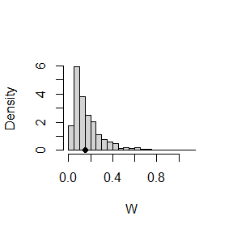

```r
hist(W, main="", freq=FALSE, breaks = "scott")
points(W0, 0, cex=1, pch=16)
```

ASL为0.426，不足以拒绝原假设.

## Question 4: Exercise 8.2

Implement the bivariate Spearman rank correlation test for independence as a permutation test. The Spearman rank correlation test statistic can be obtained from function $\mathsf{cor}$ with $\mathsf{method = "spearman"}$.

Compare the achieved significance level of the permutation test with the p-value reported by $\mathsf{cor.test}$ on the same samples.

## Answer 4:

实验所用样本来自$(X,Y)\sim N(0,\Sigma)$，其中$\Sigma=\begin{bmatrix} 1 & \sigma \\ \sigma & 1 \end{bmatrix}$.

```r
SampleGenerator <- function(n, sigma) {
  # n: 生成的样本数
  # sigma: 正态分布的参数
  # return: x和y

  Sigma <- matrix(c(1, sigma, sigma, 1), 2, 2)
  samples <- mvrnorm(n, c(0,0), Sigma)
  return(samples)
}
```

```r
SpearmanTest <- function(x, y, R) {
  # x, y: 数据
  # R: permutation重复次数
  # return: 近似ASL和p值

  test0 <- cor(x, y, method="spearman")
  tests <- replicate(R, expr = {
    x1 <- sample(x, replace=FALSE)
    cor(x1, y, method="spearman")
  })
  ASL <- mean(c(abs(tests), abs(test0)) >= abs(test0))
  p <- cor.test(x, y, method="spearman")$p.value

  return(c(ASL=ASL, p.value=p))
}
```

取样本数目$n=25$，重复次数$R=999$，对$\sigma=0.1,0.3,0.5$时的情况进行了实验.

```r
set.seed(20241027)
n <- 25
sigmas <- c(0.1, 0.3, 0.5)
R <- 999

ASLs <- c()
p.values <- c()
for (sigma in sigmas) {
  samples <- SampleGenerator(n, sigma)
  x <- samples[, 1]
  y <- samples[, 2]
  result <- SpearmanTest(x, y, R)
  ASLs <- c(ASLs, result[1])
  p.values <- c(p.values, result[2])
}

data.frame(sigma=sigmas, ASL=ASLs, p.value=p.values)
```

```
##   sigma   ASL    p.value
## 1   0.1 0.744 0.74455227
## 2   0.3 0.089 0.07713312
## 3   0.5 0.029 0.03438329
```

可见ASL和p值相近.

# HW6

## Question 1: Exercies 9.3

Use the Metropolis-Hastings sampler to generate random variables from a standard Cauchy distribution.

Discard the first 1000 of the chain, and compare the deciles of the generated observations with the deciles of the standard Cauchy distribution (see qcauchy or qt with df=1).

Recall that a $\mathrm{Cauchy}(\theta, \eta)$ distribution has density function
$$f(x)=\frac{1}{\theta\pi(1+[(x-\eta)/\theta]^2)},\quad
-\infty<x<\infty,\ \theta>0.$$
The standard Cauchy has the $\mathrm{Cauchy}(\theta = 1, \eta = 0)$ density. (Note that the standard Cauchy density is equal to the Student t density with one degree of freedom.)

## Answer 1:

使用随机游走Metropolis算法，取提议分布为$N(X_t,\sigma^2)$，则接受概率为$f(Y)/f(X_t)=\frac{\theta^2+(X_t-\eta)^2}{\theta^2+(Y-\eta)^2}$.

```r
CauchyGenerator <- function(N, theta, eta, x0, sigma) {
  # n: 生成的样本数
  # theta, eta: Cauchy分布的参数
  # x0: 初始值
  # sigma: 提议分布的参数
  # return: 长度为n的向量

  x <- numeric(N)
  x[1] <- x0
  u <- runif(N) # 用于和接受概率比较
  for (i in 2:N) {
    y <- rnorm(1, x[i-1], sigma)
    if (u[i] <= dcauchy(y, eta, theta)/dcauchy(x[i-1], eta, theta)) {
      x[i] <- y
    }
    else{
      x[i] <- x[i-1]
    }
  }
  return(x)
}
```

```r
set.seed(20241031)

N <- 5000
theta <- 1
eta <- 0
sigma <- 4
x0 <- 30

x <- CauchyGenerator(N, theta, eta, x0, sigma)
```

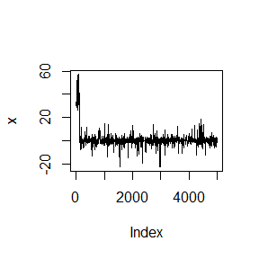

```r
plot(x, type="l")
```

收敛情况不错.

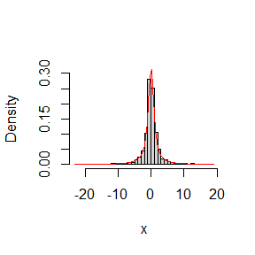

```r
hist(x[1001:5000], breaks="scott", proba=TRUE, ylim=c(0, 0.3), main="", xlab="x")
curve(dcauchy, col="red", add=TRUE)
```

从直方图来看，生成的样本符合目标分布.

```r
qs <- seq(0.1, 0.9, 0.1)
result1 <- qcauchy(qs)
result2 <- quantile(x[1001:5000], probs=qs)
data.frame(q=qs, Cauchy=result1, Observation=result2, Differece=result2-result1)
```

```
##       q     Cauchy Observation   Differece
## 10% 0.1 -3.0776835 -2.70561324  0.37207029
## 20% 0.2 -1.3763819 -1.27834858  0.09803334
## 30% 0.3 -0.7265425 -0.62777972  0.09876281
## 40% 0.4 -0.3249197 -0.28454010  0.04037960
## 50% 0.5  0.0000000 -0.03855417 -0.03855417
## 60% 0.6  0.3249197  0.25947741 -0.06544229
## 70% 0.7  0.7265425  0.64996650 -0.07657603
## 80% 0.8  1.3763819  1.23411505 -0.14226687
## 90% 0.9  3.0776835  2.41739405 -0.66028949
```

理论十分位数和样本十分位数相差不是很大，看起来离0越远的地方估计效果越差，这可能是因为Cauchy分布是个厚尾分布，导致随机游走过程中可能会长时间都留在远离0的部分.

## Question 2: Exercies 9.8

Consider the bivariate density
$$f(x,y)\propto
\binom{n}{x}y^{x+a-1}(1-y)^{n-x+b-1},\ x=0,1,\dots, n,\ 0\le y\le
1.$$
It can be shown that for fixed $a, b, n$, the conditional distributions are $\mathrm{Binomial}(n, y)$ and $\mathrm{Beta}(x + a, n − x + b)$.

Use the Gibbs sampler to generate a chain with target joint density $f(x, y)$.

## Answer 2:

```r
GibbsSampler <- function(N, z0, a, b, n) {
  # N: 生成样本数
  # z0: 初始值，一个二维向量
  # a, b, n: 目标分布的参数
  # return: Nx2的矩阵

  z <- matrix(nrow=N, ncol=2)
  z[1, ] <- z0
  x <- z0[1]
  y <- z0[2]
  for (i in 2:N) {
    x <- rbinom(1, n, y)
    y <- rbeta(1, x+a, n-x+b)
    z[i, ] <- c(x, y)
  }
  return(z)
}
```

```r
set.seed(20241101)
N <- 1000
z0 <- c(0, 0)
a <- 1
b <- 1
n <- 10
z <- GibbsSampler(N, z0, a, b, n)
```

生成效果如下：

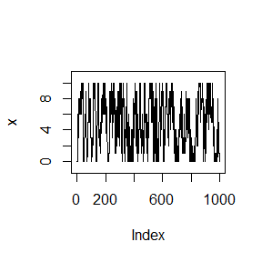

```r
plot(z[,1], type="l", ylab="x", ylim=c(-1, 11))
```

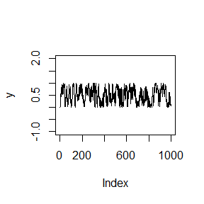

```r
plot(z[,2], type="l", ylab="y", ylim=c(-1, 2))
```

## Question 3:

For each of the above exercise, use the Gelman-Rubin method to monitor convergence of the chain, and run the chain until it converges approximately to the target distribution according to $\hat{R}<1.2$.

## Answer 3:

对于Question1，选取$\psi_{ij}$为第$i$条链直到时间$j$的样本均值. 对于Question2，选取$\psi_{ij}$为第$i$条链直到时间$j$的$y$的样本均值.

```r
GR <- function(psi) {
  n <- ncol(psi)
  k <- nrow(psi)
  psi.means <- rowMeans(psi)
  B <- n * var(psi.means)
  psi.w <- apply(psi, 1, "var")
  W <- mean(psi.w)
  v.hat <- W * (n-1)/n + B/n
  r.hat <- v.hat / W
  return(r.hat)
}
```

### Question 1:

因为Cauchy厚尾，所以随机游走容易滞留在尾部. 因此我取较大的$\sigma$，使得随机游走每一步走得尽量的远，一定程度上减少滞留的时间.

```r
set.seed(20241101)

N <- 8000
burn <- 1000
theta <- 1
eta <- 0
sigma <- 4
x0 <- c(-10, -5, 5, 10)

X <- matrix(nrow=length(x0), ncol=N)
for (i in 1:length(x0)) {
  X[i, ] <- CauchyGenerator(N, theta, eta, x0[i], sigma)
}

psi <- t(apply(X, 1, cumsum))
for (i in 1:nrow(psi)) {
  psi[i, ] <- psi[i, ] / (1:ncol(psi))
}
rhat <- rep(0, N)
for (j in (burn+1):N) {
  rhat[j] <- GR(psi[,1:j])
}
```

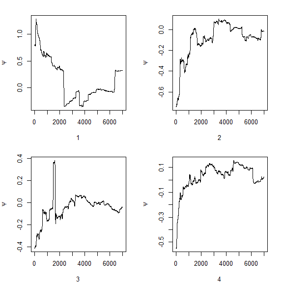

```r
par(mfrow=c(2, 2))
par(mar=c(4, 4, 2, 2))
for (i in 1:length(x0)) {
  plot(psi[i, (burn+1):N], type="l", xlab=i, ylab=bquote(psi))
}
```

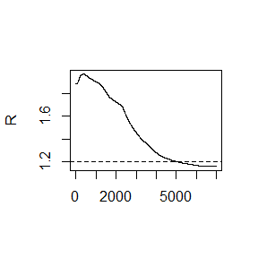

```r
plot(rhat[(burn+1):N], type="l", xlab="", ylab="R")
abline(h=1.2, lty=2)
```

```r
N0 <- which(rhat[(burn+1):N]<1.2)[1]
N0
```

```
## [1] 5078
```

N0即为$\hat{R}$第一次小于1.2的时刻.

N0之前的链如下所示：

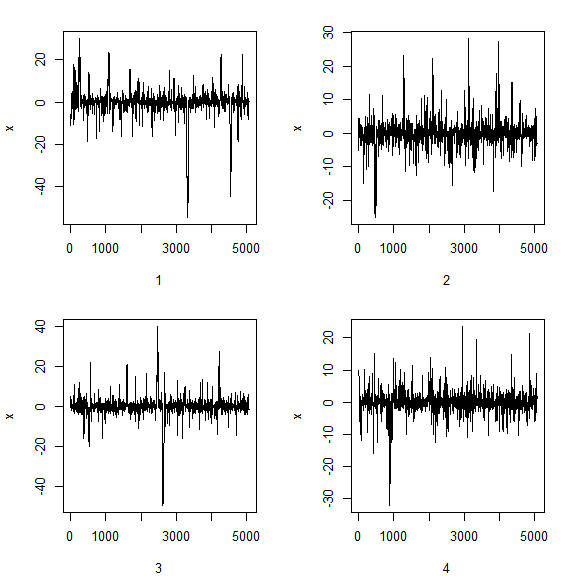

```r
par(mfrow=c(2, 2))
par(mar=c(4, 4, 2, 2))
for (i in 1:length(x0)) {
  plot(X[i, 1:N0], type="l", xlab=i, ylab="x")
}
```

### Question 2:

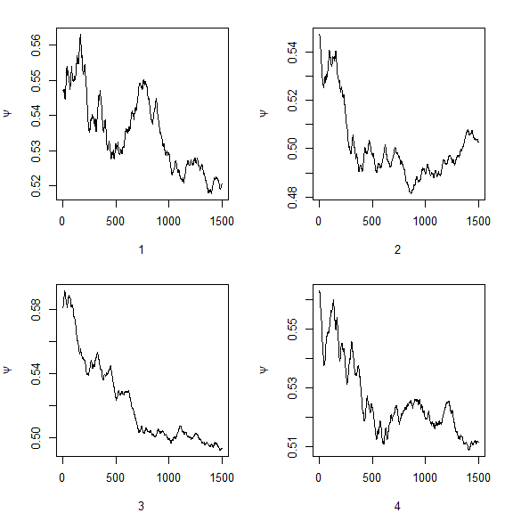

```r
set.seed(20241102)

N <- 2000
burn <- 500
x0 <- c(0, 0, 0, 0)
y0 <- c(0.2, 0.4, 0.6, 0.8)
a <- 1
b <- 1
n <- 10

X <- matrix(nrow=length(x0), ncol=N)
Y <- matrix(nrow=length(x0), ncol=N)
for (i in 1:length(x0)) {
  z <- GibbsSampler(N, c(x0[i], y0[i]), a, b, n)
  X[i, ] <- as.numeric(z[, 1])
  Y[i, ] <- as.numeric(z[, 2])
}

psi <- t(apply(Y, 1, cumsum))
for (i in 1:nrow(psi)) {
  psi[i, ] <- psi[i, ] / (1:ncol(psi))
}
rhat <- rep(0, N)
for (j in (burn+1):N) {
  rhat[j] <- GR(psi[,1:j])
}

par(mfrow=c(2,2))
par(mar=c(4, 4, 2, 2))
for (i in 1:length(x0)) {
  plot(psi[i, (burn+1):N], type="l", xlab=i, ylab=bquote(psi))
}
```

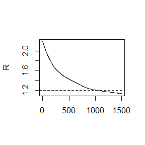

```r
par(mfrow=c(1,1))
plot(rhat[(burn+1):N], type="l", xlab="", ylab="R")
abline(h=1.2, lty=2)
```

```r
N0 <- which(rhat[(burn+1):N]<1.2)[1]
N0
```

```
## [1] 1011
```

N0即为$\hat{R}$第一次小于1.2的时刻.

N0之前的链如下所示：

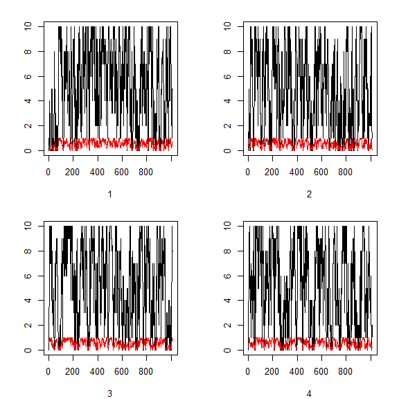

```r
par(mfrow=c(2,2))
par(mar=c(4, 4, 2, 2))
for (i in 1:length(x0)) {
  plot(X[i, 1:N0], type="l", xlab=i, ylab="")
  lines(Y[i, 1:N0], col="red")
}
```

# HW7

## Question 1: Exercise 11.3

1. Write a function to compute the $k$th term in
   $$\sum_{k=0}^\infty\frac{(-1)^k}{k!2^k}\frac{\|a\|^{2k+2}}{(2k+1)(2k+2)}\frac{\Gamma\left(\frac{d+1}{2}\right)\Gamma\left(k+\frac{3}{2}\right)}{\Gamma\left(k+\frac{d}{2}+1\right)},$$
   where $d \ge 1$ is an integer, $a$ is a vector in $\mathbb{R}^d$, and $\|\cdot\|$ denotes the Euclidean norm.

Perform the arithmetic so that the coefficients can be computed for (almost) arbitrarily large $k$ and $d$. (This sum converges for all $a\in\mathbb{R}^d$.

2. Modify the function so that it computes and returns the sum.
3. Evaluate the sum when $a = (1, 2)^T$ .

## Answer 1:

### (a).

```r
kthTerm <- function(d, a, k) {
  return((-1)^k*exp((k+1)*log(sum(a^2))+lgamma((d+1)/2)+lgamma(k+1.5)-lgamma(k+1)-k*log(2)-lgamma(k+d/2+1)))
}
```

```r
ks <- c(2, 5, 10, 100, 101, 10000, 10001)
ds <- c(2, 5, 10, 100, 101, 10000, 10001)

set.seed(20241107)
result <- c()
for (k in ks) {
  for (d in ds) {
    a <- rnorm(d) # 随机取一个a
    result <- c(result, kthTerm(d, a, k))
  }
}
result
```

```
##  [1]   3.541354e-02   6.809568e-02   1.869390e+01   3.156161e+01   1.254191e+01
##  [6]   2.354409e+02   2.579831e+02  -8.198494e-01  -3.288205e-02  -2.802165e+00
## [11]  -3.260685e+00  -3.503236e+01  -2.911114e+02  -3.687126e+02   4.612496e-14
## [16]   1.949533e-08   3.222687e-01   3.680398e+01   1.201279e+01   4.251364e+02
## [21]   3.814412e+02  5.126006e-195  7.506371e-124  2.259044e-102   9.935498e-30
## [26]   5.465263e-29   4.354534e+02   2.432012e+02 -2.543752e-256 -1.488516e-227
## [31]  -2.366522e-96  -1.307243e-30  -2.348179e-20  -6.728979e+02  -8.399083e+01
## [36]   0.000000e+00   0.000000e+00   0.000000e+00   0.000000e+00   0.000000e+00
## [41]   0.000000e+00   0.000000e+00   0.000000e+00   0.000000e+00   0.000000e+00
## [46]   0.000000e+00   0.000000e+00   0.000000e+00   0.000000e+00
```

可见对于几乎任意大的$k$和$d$，上述函数仍然能有效运行.

### (b).

```r
SumComputer <- function(d, a, error) {
  result <- kthTerm(d, a, 0)
  k <- 1
  term <- kthTerm(d, a, k)
  while (term > error) {
    result <- result + term
    k <- k + 1
    term <- kthTerm(d, a, k)
  }
  return(result)
}
```

```r
set.seed(20241107)
error <- 1e-5
result <- c()
for (d in ds) {
  a <- rnorm(d) # 随机取一个a
  result <- c(result, SumComputer(d, a, error))
}
result
```

```
## [1]   0.6539126   0.8666002   6.3020656  14.0792633  10.3835497 125.4333810
## [7] 129.3195055
```

运行效果不错.

### (c).

```r
d <- 2
a <- c(1, 2)
error <- 1e-5
SumComputer(d, a, error)
```

```
## [1] 3.926991
```

## Question 2: Exercise 11.5

Write a function to solve the equation
$$\frac{2\Gamma\left(\frac{k}{2}\right)}{\sqrt{\pi(k-1)}\Gamma\left(\frac{k-1}{2}\right)}\int_0^{c_{k-1}}\left(1+\frac{u^2}{k-1}\right)^{-k/2}\mathrm{d}u=\frac{2\Gamma\left(\frac{k+1}{2}\right)}{\sqrt{\pi
k}\Gamma\left(\frac{k}{2}\right)}\int_0^{c_k}\left(1+\frac{u^2}{k}\right)^{-(k+1)/2}\mathrm{d}u$$
for a, where
$$c_k=\sqrt{\frac{a^2k}{k+1-a^2}}.$$
Compare the solutions with the points $A(k)$ in Exercise 11.4.

## Answer 2:

### 计算零点:

```r
# 被积函数
f <- function(x, k) {
  return((1+x^2/k)^(-k/2))
}

# 计算c_k
ck <- function(a, k) {
  return(sqrt(a^2*k/(k+1-a^2)))
}
```

```r
EquationSolver <- function(k, interval) {
  target <- function(a) {
    c1 <- ck(a, k-1)
    c2 <- ck(a, k)
    I1 <- integrate(f, lower=0, upper=c1, k=k-1)$value
    I2 <- integrate(f, lower=0, upper=c2, k=k)$value
    return(lgamma(k/2)-0.5*log(k-1)-lgamma((k-1)/2)+log(I1)-lgamma((k+1)/2)+0.5*log(k)+lgamma(k/2)-log(I2))
  }
  solution <- uniroot(target, interval)
  return(solution$root)
}
```

```r
ks <- c(4:25, 100, 500, 1000)
result1 <- c()
for (k in ks) {
  result1 <- c(result1, EquationSolver(k, c(0.01, sqrt(k)-0.01)))
}
data.frame(k=ks, solution=result1)
```

```
##       k solution
## 1     4 1.207461
## 2     5 1.216637
## 3     6 1.222491
## 4     7 1.226471
## 5     8 1.229362
## 6     9 1.231550
## 7    10 1.233261
## 8    11 1.234635
## 9    12 1.235761
## 10   13 1.236701
## 11   14 1.237505
## 12   15 1.238177
## 13   16 1.238768
## 14   17 1.239286
## 15   18 1.239742
## 16   19 1.240149
## 17   20 1.240510
## 18   21 1.240838
## 19   22 1.241138
## 20   23 1.241418
## 21   24 1.241673
## 22   25 1.241869
## 23  100 1.245757
## 24  500 1.246769
## 25 1000 1.246866
```

### 比较:

```r
result2 <- c()
for (k in ks) {
  solution <- uniroot(f=function(a) {
    pt(ck(a, k-1), k-1, lower.tail=FALSE)-pt(ck(a, k), k, lower.tail=FALSE)
    },
    c(0.01, sqrt(k)-0.01))
  result2 <- c(result2, solution$root)
}
data.frame(k=ks, sqrt.k=sqrt(ks), Exercise11.4=result2, Exercise11.5=result1)
```

```
##       k    sqrt.k Exercise11.4 Exercise11.5
## 1     4  2.000000     1.492073     1.207461
## 2     5  2.236068     1.533555     1.216637
## 3     6  2.449490     1.562745     1.222491
## 4     7  2.645751     1.584429     1.226471
## 5     8  2.828427     1.601184     1.229362
## 6     9  3.000000     1.614516     1.231550
## 7    10  3.162278     1.625389     1.233261
## 8    11  3.316625     1.634418     1.234635
## 9    12  3.464102     1.642026     1.235761
## 10   13  3.605551     1.648552     1.236701
## 11   14  3.741657     1.654175     1.237505
## 12   15  3.872983     1.659099     1.238177
## 13   16  4.000000     1.663454     1.238768
## 14   17  4.123106     1.667287     1.239286
## 15   18  4.242641     1.670733     1.239742
## 16   19  4.358899     1.673832     1.240149
## 17   20  4.472136     1.676605     1.240510
## 18   21  4.582576     1.679148     1.240838
## 19   22  4.690416     1.681468     1.241138
## 20   23  4.795832     1.683593     1.241418
## 21   24  4.898979     1.685546     1.241673
## 22   25  5.000000     1.687366     1.241869
## 23  100 10.000000     1.720607     1.245757
## 24  500 22.360680    22.350680     1.246769
## 25 1000 31.622777    31.612777     1.246866
```

注意到Exercise 11.4得到的结果总是比Exercise 11.5得到的结果大，并且从$k=500$开始，Exercise 11.4倾向于取右端点$a=\sqrt{k}-0.01$而不能求得真正的解.

## Question 3:

Suppose $T_1,\dots, T_n$ are i.i.d. samples drawn from the exponential distribution with expectation $\lambda$. Those values greater than $\tau$ are not observed due to right censorship, so that the observed values are $Y_i = T_iI(T_i ≤ \tau ) + \tau I(T_i > τ ),\ i = 1,\dots , n$. Suppose $\tau=1$ and the observed $Y_i$ values are as follows:
$$0.54, 0.48, 0.33, 0.43, 1.00, 1.00, 0.91, 1.00,
0.21, 0.85$$
Use the E-M algorithm to estimate $\lambda$, compare your result with the observed data MLE (note: Yi follows a mixture distribution).

## Answer 3:

### EM算法

$T_1,\dots,T_n$的对数似然为
$$l=\sum_{i=1}^n\log\left(\frac{1}{\lambda}e^{-T_i/\lambda}\right)=-\frac{1}{\lambda}\sum_{i=1}^nT_i-n\log(\lambda).$$

观测数据设为$T_1,\dots,T_m$和$X_{m+1}=I(T_{m+1}>\tau),\cdots,X_n=I(T_{n}>\tau)$，记$X^{(0)}=(T_1,\dots,T_m,X_{m+1},\dots,X_n)$.

E-Step:

$$l_k=\mathbb{E}_{\hat{\lambda}_k}(l|X^{(o)})=-\frac{1}{\lambda}\sum_{i=1}^mT_i-\frac{1}{\lambda}\sum_{i=m+1}^n\mathbb{E}(T_i|X_i)-n\log(\lambda).$$

在$X_i$均为1的情况下，上式等于
$$l_k=-\frac{1}{\lambda}\sum_{i=1}^mT_i-\frac{n-m}{\lambda}(\hat\lambda_k+\tau)-n\log\lambda.$$

M-Step:

$$\frac{\partial
l_k}{\partial\lambda}=\frac{1}{\lambda^2}\sum_{i=1}^m
T_i+\frac{(n-m)(\hat{\lambda}_k+\tau)}{\lambda^2}-\frac{n}{\lambda}.$$

因此
$$\hat{\lambda}_{k+1}=\frac{1}{n}\sum_{i=1}^mT_i+\frac{n-m}{n}(\hat\lambda_k+\tau)=\frac{1}{n}\sum_{i=1}^nY_i+\frac{n-m}{n}\hat\lambda_k.$$

```r
Ys <- c(0.54, 0.48, 0.33, 0.43, 1.00, 1.00, 0.91, 1.00, 0.21, 0.85)
```

```r
EM <- function(Ys, N, lambda0) {
  lambda <- lambda0
  m <- sum(Ys<1)
  n <- length(Ys)
  for (i in 1:N) {
    lambda <- mean(Ys) + (1 - m/n)*lambda
  }
  return(lambda)
}
```

```r
lambda1 <- EM(Ys, 100, 0.1)
lambda1
```

```
## [1] 0.9642857
```

### MLE

$P(Y_i=1)=e^{-1/\lambda}$，因此$Y_1,\dots,Y_n$的对数似然为
$$l=\sum_{i=1}^n\left[\log\left(\frac{1}{\lambda}e^{-Y_i/\lambda}\right)I(Y_i<1)+\log(e^{-1/\lambda})I(Y_i=1)\right].$$
则
$$\frac{\partial
l}{\partial\lambda}=-\frac{\sum_{i=1}^nI(Y_i<1)}{\lambda}+\frac{\sum_{i=1}^nY_iI(Y_i<1)}{\lambda^2}+\frac{\sum_{i=1}^nI(Y_i=1)}{\lambda^2}.$$
因此MLE为
$$\hat{\lambda}=\frac{\sum_{i=1}^nY_iI(Y_i<1)+\sum_{i=1}^nI(Y_i=1)}{\sum_{i=1}^nI(Y_i<1)}=\frac{\sum_{i=1}^n
Y_i}{\sum_{i=1}^nI(Y_i<1)}.$$

```r
lambda2 <- sum(Ys)/sum(Ys<1)
lambda2
```

```
## [1] 0.9642857
```

可见两种估计的结果一致.

# HW8

## Question 1:

Use the simplex algorithm to solve the following problem. Minimize $4x + 2y + 9z$ subject to
$$\begin{aligned}
& 2x + y + z ≤ 2 \\
& x − y + 3z ≤ 3 \\
& x ≥ 0, y ≥ 0, z ≥ 0.
\end{aligned}$$

## Answer 1:

```r
f.obj <- c(4, 2, 9)
f.con <- matrix(c(2, 1, 1, -1, 1, 3), nrow=2, ncol=3)
f.dir <- rep("<=", 2)
f.rhs <- c(2, 3)
res.lp <- lp("min", f.obj, f.con, f.dir, f.rhs)
res.lp$solution
```

```
## [1] 0 0 0
```

可见最小值为0.

## Question 2:

Use both for loops and `lapply()` to fit linear models to the `mtcars` using the formulas stored in this list:

```r
formulas <- list(
  mpg ~ disp,
  mpg ~ I(1 / disp),
  mpg ~ disp + wt,
  mpg ~ I(1 / disp) + wt
)
```

## Answer 2:

```r
formulas <- list(
  mpg ~ disp,
  mpg ~ I(1 / disp),
  mpg ~ disp + wt,
  mpg ~ I(1 / disp) + wt
)
```

```r
lms21 <- list()
for (i in 1:4) {
  lms21[[i]] <- lm(formulas[[i]], mtcars)
}
lms21
```

```
## [[1]]
##
## Call:
## lm(formula = formulas[[i]], data = mtcars)
##
## Coefficients:
## (Intercept)         disp
##    29.59985     -0.04122
##
##
## [[2]]
##
## Call:
## lm(formula = formulas[[i]], data = mtcars)
##
## Coefficients:
## (Intercept)    I(1/disp)
##       10.75      1557.67
##
##
## [[3]]
##
## Call:
## lm(formula = formulas[[i]], data = mtcars)
##
## Coefficients:
## (Intercept)         disp           wt
##    34.96055     -0.01772     -3.35083
##
##
## [[4]]
##
## Call:
## lm(formula = formulas[[i]], data = mtcars)
##
## Coefficients:
## (Intercept)    I(1/disp)           wt
##      19.024     1142.560       -1.798
```

```r
lms22 <- lapply(formulas, lm, data=mtcars)
lms22
```

```
## [[1]]
##
## Call:
## FUN(formula = X[[i]], data = ..1)
##
## Coefficients:
## (Intercept)         disp
##    29.59985     -0.04122
##
##
## [[2]]
##
## Call:
## FUN(formula = X[[i]], data = ..1)
##
## Coefficients:
## (Intercept)    I(1/disp)
##       10.75      1557.67
##
##
## [[3]]
##
## Call:
## FUN(formula = X[[i]], data = ..1)
##
## Coefficients:
## (Intercept)         disp           wt
##    34.96055     -0.01772     -3.35083
##
##
## [[4]]
##
## Call:
## FUN(formula = X[[i]], data = ..1)
##
## Coefficients:
## (Intercept)    I(1/disp)           wt
##      19.024     1142.560       -1.798
```

## Question 3:

Fit the model `mpg ~ disp` to each of the bootstrap replicates of `mtcars` in the list below by using a for loop and `lapply()`. Can you do it without an anonymous function?

```r
bootstraps <- lapply(1:10, function(i) {
  rows <- sample(1:nrow(mtcars), rep = TRUE)
  mtcars[rows, ]
})
```

## Answer 3:

```r
set.seed(20241114)
bootstraps <- lapply(1:10, function(i) {
  rows <- sample(1:nrow(mtcars), rep = TRUE)
  mtcars[rows, ]
})
```

```r
lms31 <- list()
for (i in 1:10) {
  lms31[[i]] <- lm(mpg ~ disp, bootstraps[[i]])
}
lms31
```

```
## [[1]]
##
## Call:
## lm(formula = mpg ~ disp, data = bootstraps[[i]])
##
## Coefficients:
## (Intercept)         disp
##    30.96839     -0.04381
##
##
## [[2]]
##
## Call:
## lm(formula = mpg ~ disp, data = bootstraps[[i]])
##
## Coefficients:
## (Intercept)         disp
##    31.70091     -0.04663
##
##
## [[3]]
##
## Call:
## lm(formula = mpg ~ disp, data = bootstraps[[i]])
##
## Coefficients:
## (Intercept)         disp
##    29.91196     -0.04323
##
##
## [[4]]
##
## Call:
## lm(formula = mpg ~ disp, data = bootstraps[[i]])
##
## Coefficients:
## (Intercept)         disp
##    31.76612     -0.04925
##
##
```

[output cut: 43 more lines]

```
## lm(formula = mpg ~ disp, data = bootstraps[[i]])
##
## Coefficients:
## (Intercept)         disp
##    29.90533     -0.04271
##
##
## [[10]]
##
## Call:
## lm(formula = mpg ~ disp, data = bootstraps[[i]])
##
## Coefficients:
## (Intercept)         disp
##    27.47461     -0.03316
```

```r
lms32 <- lapply(bootstraps, lm, formula=mpg ~ disp)
lms32
```

```
## [[1]]
##
## Call:
## FUN(formula = ..1, data = X[[i]])
##
## Coefficients:
## (Intercept)         disp
##    30.96839     -0.04381
##
##
## [[2]]
##
## Call:
## FUN(formula = ..1, data = X[[i]])
##
## Coefficients:
## (Intercept)         disp
##    31.70091     -0.04663
##
##
## [[3]]
##
## Call:
## FUN(formula = ..1, data = X[[i]])
##
## Coefficients:
## (Intercept)         disp
##    29.91196     -0.04323
##
##
## [[4]]
##
## Call:
## FUN(formula = ..1, data = X[[i]])
##
## Coefficients:
## (Intercept)         disp
##    31.76612     -0.04925
##
##
```

[output cut: 43 more lines]

```
## FUN(formula = ..1, data = X[[i]])
##
## Coefficients:
## (Intercept)         disp
##    29.90533     -0.04271
##
##
## [[10]]
##
## Call:
## FUN(formula = ..1, data = X[[i]])
##
## Coefficients:
## (Intercept)         disp
##    27.47461     -0.03316
```

如果不使用匿名函数，代码如下

```r
set.seed(20241116)
lms33 <- list()
for (i in 1:10) {
  rows <- sample(1:nrow(mtcars), rep=TRUE)
  lms33[[i]] <- lm(formula=mpg~disp ,data=mtcars[rows,])
}
lms33
```

```
## [[1]]
##
## Call:
## lm(formula = mpg ~ disp, data = mtcars[rows, ])
##
## Coefficients:
## (Intercept)         disp
##    29.69501     -0.04115
##
##
## [[2]]
##
## Call:
## lm(formula = mpg ~ disp, data = mtcars[rows, ])
##
## Coefficients:
## (Intercept)         disp
##    29.80785     -0.04244
##
##
## [[3]]
##
## Call:
## lm(formula = mpg ~ disp, data = mtcars[rows, ])
##
## Coefficients:
## (Intercept)         disp
##    28.91877     -0.04082
##
##
## [[4]]
##
## Call:
## lm(formula = mpg ~ disp, data = mtcars[rows, ])
##
## Coefficients:
## (Intercept)         disp
##    31.00939     -0.04628
##
##
```

[output cut: 43 more lines]

```
## lm(formula = mpg ~ disp, data = mtcars[rows, ])
##
## Coefficients:
## (Intercept)         disp
##     30.4483      -0.0446
##
##
## [[10]]
##
## Call:
## lm(formula = mpg ~ disp, data = mtcars[rows, ])
##
## Coefficients:
## (Intercept)         disp
##    31.64238     -0.04915
```

## Question 4:

For each model in the previous two exercises, extract $R^2$ using the function below.

```r
rsq <- function(mod) summary(mod)$r.squared
```

## Answer 4:

```r
rsq <- function(mod) summary(mod)$r.squared
```

```r
rs2 <- lapply(lms22, rsq) # Question2的模型
rs3 <- lapply(lms32, rsq) # Question3的模型
as.numeric(rs2)
```

```
## [1] 0.7183433 0.8596865 0.7809306 0.8838038
```

```r
as.numeric(rs3)
```

```
##  [1] 0.7005150 0.7743866 0.7347297 0.7669243 0.7559898 0.6546903 0.8312877
##  [8] 0.7529622 0.6977379 0.6593471
```

## Question 5:

The following code simulates the performance of a t-test for non-normal data. Use `sapply()` and an anonymous function to extract the p-value from every trial.

```r
trials <- replicate(
  100,
  t.test(rpois(10, 10), rpois(7, 10)),
  simplify = FALSE
)
```

Extra challenge: get rid of the anonymous function by using `[[` directly.

## Answer 5:

```r
set.seed(20241116)
trials <- replicate(
  100,
  t.test(rpois(10, 10), rpois(7, 10)),
  simplify=FALSE
)

sapply(trials, function(trial) trial$p.value)
```

```
##   [1] 0.048992381 0.224751390 0.008690355 0.551448947 0.721698488 0.032845422
##   [7] 0.805104529 0.020180967 0.259555290 0.019147479 0.944756489 0.869429946
##  [13] 0.553637661 0.416586738 0.345008403 0.581250736 0.348179355 0.861954133
##  [19] 0.828501008 0.613204415 0.863329338 0.787209589 0.146408775 0.228681554
##  [25] 0.943050945 0.168174917 0.336473442 0.235001878 0.262447127 0.573592631
##  [31] 0.054003994 0.228673069 0.261405316 0.811792792 0.171856746 0.601685939
##  [37] 0.065479295 0.498554760 0.417241561 0.515797639 0.949731258 0.592490799
##  [43] 0.546204586 0.548417759 0.597316362 0.535122608 0.021773069 0.808323651
##  [49] 0.635605572 0.677015235 0.018144807 0.666194705 0.946421280 0.337121338
##  [55] 0.423997175 0.334820024 0.888295671 0.942855017 0.299359292 0.309643133
##  [61] 0.305446504 0.291457783 0.113001404 0.931572970 0.219978043 0.160250030
##  [67] 0.095276865 0.139273371 0.421737376 0.846930022 0.379917483 0.136128997
##  [73] 0.410146338 0.442244584 0.049136670 0.365238174 0.077584252 0.678253402
##  [79] 0.786358335 0.426125190 0.304676607 0.708081886 0.654393723 0.320867186
##  [85] 0.591635058 0.503868674 0.895891526 0.791125310 0.291497708 0.417087713
##  [91] 0.158276185 0.678324948 0.371728385 0.383465293 0.285780373 0.665902778
##  [97] 0.470552263 0.230436742 0.636284795 0.545425755
```

如果不使用匿名函数而是使用[[，代码如下

```r
sapply(trials, '[[', "p.value")
```

```
##   [1] 0.048992381 0.224751390 0.008690355 0.551448947 0.721698488 0.032845422
##   [7] 0.805104529 0.020180967 0.259555290 0.019147479 0.944756489 0.869429946
##  [13] 0.553637661 0.416586738 0.345008403 0.581250736 0.348179355 0.861954133
##  [19] 0.828501008 0.613204415 0.863329338 0.787209589 0.146408775 0.228681554
##  [25] 0.943050945 0.168174917 0.336473442 0.235001878 0.262447127 0.573592631
##  [31] 0.054003994 0.228673069 0.261405316 0.811792792 0.171856746 0.601685939
##  [37] 0.065479295 0.498554760 0.417241561 0.515797639 0.949731258 0.592490799
##  [43] 0.546204586 0.548417759 0.597316362 0.535122608 0.021773069 0.808323651
##  [49] 0.635605572 0.677015235 0.018144807 0.666194705 0.946421280 0.337121338
##  [55] 0.423997175 0.334820024 0.888295671 0.942855017 0.299359292 0.309643133
##  [61] 0.305446504 0.291457783 0.113001404 0.931572970 0.219978043 0.160250030
##  [67] 0.095276865 0.139273371 0.421737376 0.846930022 0.379917483 0.136128997
##  [73] 0.410146338 0.442244584 0.049136670 0.365238174 0.077584252 0.678253402
##  [79] 0.786358335 0.426125190 0.304676607 0.708081886 0.654393723 0.320867186
##  [85] 0.591635058 0.503868674 0.895891526 0.791125310 0.291497708 0.417087713
##  [91] 0.158276185 0.678324948 0.371728385 0.383465293 0.285780373 0.665902778
##  [97] 0.470552263 0.230436742 0.636284795 0.545425755
```

## Question 6:

Implement a combination of `Map()` and `vapply()` to create an `lapply()` variant that iterates in parallel over all of its inputs and stores its outputs in a vector (or a matrix). What arguments should the function take?

## Answer 6:

```r
Newlappy <- function(fun, ..., FUN.VALUE) {
  tmp <- Map(fun, ...)
  result <- vapply(tmp, FUN=identity, FUN.VALUE=FUN.VALUE)
  return(result)
}
```

通过一个例子来检验

```r
a <- list(c(1, 2, 3, 4, 5), c(1, 1, 1))
b <- list(c(5, 4, 3, 2, 1), c(2, 2, 2))
Newlappy(function(x,y) mean(x+y), a, b, FUN.VALUE=numeric(1))
```

```
## [1] 6 3
```

## Question 7:

Make a faster version of `chisq.test()` that only computes the chi-square test statistic when the input is two numeric vectors with no missing values. You can try simplifying `chisq.test()` or by coding from the mathematical definition.

## Answer 7:

```r
NewChisqTest <- function(x, y) {
  data <- table(x, y)
  N <- length(x)
  row_nums <- rowSums(data)
  col_nums <- colSums(data)

  Es <- matrix(0, nrow = nrow(data), ncol = ncol(data))
  for (i in 1:nrow(data)) {
    for (j in 1:ncol(data)) {
      Es[i, j] <- (row_nums[i] * col_nums[j]) / N
    }
  }

  data <- as.numeric(data)
  Es <- as.numeric(Es)
  result <- sum((data - Es)^2 / Es)

  return(result)
}
```

用一个实验来验证此函数的正确性和快速性

```r
set.seed(20241116)
x <- sample(1:5, 50, replace=TRUE)
y <- sample(1:2, 50, replace=TRUE)

test1 <- as.numeric(chisq.test(table(x, y))$statistic)
test2 <- NewChisqTest(x, y)

time1 <- replicate(
  1000,
  expr= {
    start1 <- Sys.time()
    test1 <- as.numeric(chisq.test(table(x, y))$statistic)
    end1 <- Sys.time()
    end1 - start1
  })

time2 <- replicate(
  1000,
  expr= {
    start2 <- Sys.time()
    test2 <- NewChisqTest(x, y)
    end2 <- Sys.time()
    end2 - start2
  })

data.frame(fun=c("chisq.test", "New"), value=c(test1, test2), time=c(mean(time1), mean(time2)))
```

```
##          fun    value         time
## 1 chisq.test 8.931568 0.0004590490
## 2        New 8.931568 0.0003053987
```

可见新函数的计算结果是准确的，并且运行时间更短.

## Question 8:

Can you make a faster version of `table()` for the case of an input of two integer vectors with no missing values? Can you use it to speed up your chi-square test?

## Answer 8:

```r
NewTable <- function(x, y) {
  x.new <- unique(x)
  y.new <- unique(y)
  result <- matrix(0, nrow=length(x.new), ncol=length(y.new))
  rownames(result) <- x.new
  colnames(result) <- y.new

  for (i in 1:length(x)) {
    row_index <- match(x[i], x.new)
    col_index <- match(y[i], y.new)
    result[row_index, col_index] <- result[row_index, col_index]+1
  }

  return(result)
}
```

下面用一个实验来检验此函数

```r
set.seed(20241116)
x <- sample(1:5, 50, replace=TRUE)
y <- sample(1:2, 50, replace=TRUE)

result1 <- table(x, y)
result2 <- NewTable(x, y)

time1 <- replicate(
  1000,
  expr= {
    start1 <- Sys.time()
    test1 <- table(x, y)
    end1 <- Sys.time()
    end1 - start1
  })

time2 <- replicate(
  1000,
  expr= {
    start2 <- Sys.time()
    test2 <- NewTable(x, y)
    end2 <- Sys.time()
    end2 - start2
  })
```

```r
result1
```

```
##    y
## x    1  2
##   1  2 11
##   2  8  3
##   3  6  4
##   4  5  6
##   5  2  3
```

```r
mean(time1)
```

```
## [1] 0.0001981878
```

```r
result2
```

```
##    2 1
## 1 11 2
## 5  3 2
## 3  4 6
## 4  6 5
## 2  3 8
```

```r
mean(time2)
```

```
## [1] 0.0001009576
```

可见新函数结果准确并且速度更快.

如果将此函数使用到我的卡方检验函数中，可得如下函数

```r
NewNewChisqTest <- function(x, y) {
  data <- NewTable(x, y)
  N <- length(x)
  row_nums <- rowSums(data)
  col_nums <- colSums(data)

  Es <- matrix(0, nrow = nrow(data), ncol = ncol(data))
  for (i in 1:nrow(data)) {
    for (j in 1:ncol(data)) {
      Es[i, j] <- (row_nums[i] * col_nums[j]) / N
    }
  }

  data <- as.numeric(data)
  Es <- as.numeric(Es)
  result <- sum((data - Es)^2 / Es)

  return(result)
}
```

```r
set.seed(20241116)
x <- sample(1:5, 50, replace=TRUE)
y <- sample(1:2, 50, replace=TRUE)

test1 <- as.numeric(chisq.test(table(x, y))$statistic)
test2 <- NewChisqTest(x, y)
test3 <- NewNewChisqTest(x, y)


time1 <- replicate(
  1000,
  expr= {
    start1 <- Sys.time()
    test1 <- as.numeric(chisq.test(table(x, y))$statistic)
    end1 <- Sys.time()
    end1 - start1
  })

time2 <- replicate(
  1000,
  expr= {
    start2 <- Sys.time()
    test2 <- NewChisqTest(x, y)
    end2 <- Sys.time()
    end2 - start2
  })

time3 <- replicate(
  1000,
  expr= {
    start3 <- Sys.time()
    test3 <- NewNewChisqTest(x, y)
    end3 <- Sys.time()
    end3 - start3
  })

data.frame(fun=c("chisq.test", "New", "NewNew"), value=c(test1, test2, test3), time=c(mean(time1), mean(time2), mean(time3)))
```

```
##          fun    value         time
## 1 chisq.test 8.931568 0.0004387267
## 2        New 8.931568 0.0002349319
## 3     NewNew 8.931568 0.0001372473
```

可见结果准确，并且速度更快.

# HW9

## Question

Consider the bivariate density

$$f(x, y) \propto\binom{n}{x}y^{x+a−1}(1 − y)^{n−x+b−1},\quad x = 0, 1,
\dots , n,\ 0 ≤ y ≤ 1.$$
It can be shown that for fixed $a, b, n$, the conditional distributions are $\mathrm{Binomial}(n, y)$ and $\mathrm{Beta}(x + a, n − x + b)$. Write an Rcpp function using the Gibbs sampler to generate a chain with target joint density $f(x, y)$.

Compare the corresponding generated random numbers with those by the R function you wrote using the function “qqplot”.

Campare the computation time of the two functions with the function “microbenchmark”.

Comments your results.

## Answer

```r
GibbsR <- function(N, a, b, n) {
  # N: 生成样本数
  # a, b, n: 目标分布的参数
  # return: Nx2的矩阵

  z <- matrix(nrow=N, ncol=2)
  z[1, ] <- c(0, 0)
  x <- 0
  y <- 0.2
  for (i in 2:N) {
    x <- rbinom(1, n, y)
    y <- rbeta(1, x+a, n-x+b)
    z[i, ] <- c(x, y)
  }
  return(z)
}
```

```r
set.seed(20241123)
N <- 1000
burn <- 500
a <- 1
b <- 1
n <- 10
result1 <- GibbsR(N, a, b, n)
result2 <- GibbsC(N, a, b, n)
```

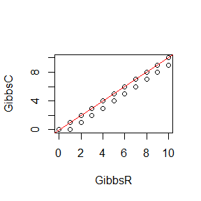

```r
qqplot(result1[(burn+1):N,1], result2[(burn+1):N,1], xlab="GibbsR", ylab="GibbsC")
abline(0, 1, col="red")
```

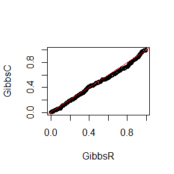

```r
qqplot(result1[(burn+1):N,2], result2[(burn+1):N,2], xlab="GibbsR", ylab="GibbsC")
abline(0, 1, col="red")
```

从Q-Q图来看两个函数生成随机数的分布是相近的.

```r
ts <- microbenchmark(gibbR=GibbsR(N, a, b, n),
                     gibbC=GibbsC(N, a, b, n))
summary(ts)[, c(1, 3, 5, 6)]
```

```
##    expr      lq  median      uq
## 1 gibbR 2422.70 2631.35 2869.80
## 2 gibbC  215.25  229.25  244.55
```

可见GibbsC的速度远远快于GibbsR.

使用C++确实能极大地提高R程序的效率.